# Amazon Customer Review Analysis: Unlocking Insights into Consumer Satisfaction and Preferences

Hamza_and_vaneeza

2023-03-20

#### Loading required Libraries

```r
suppressMessages(library(nnet))
suppressMessages(library(broom))
suppressMessages(library(knitr))
suppressMessages(library(mfx))
suppressMessages(library(systemfit))
suppressMessages(library(stargazer))
suppressMessages(library(lmtest))
suppressMessages(library(gridExtra))
suppressMessages(library(ggplot2))
suppressMessages(library(tseries))
suppressMessages(library(car))
suppressMessages(library(readxl))
suppressMessages(library(dynlm))
suppressMessages(library(forecast))
suppressMessages(library(truncreg))
suppressMessages(library(censReg))
suppressMessages(library(magrittr))
suppressMessages(library(plm))
suppressMessages(library(mice))
suppressMessages(library(GGally))
suppressMessages(library(dplyr))
suppressMessages(library(tm))
suppressMessages(library(SnowballC))
suppressMessages(library(wordcloud))
suppressMessages(library(naniar))
suppressMessages(library(tidyverse))
suppressMessages(library(tidyr))
suppressMessages(library(corrplot))
suppressMessages(library(kableExtra))
suppressMessages(library(tm))
suppressMessages(library(quanteda))
suppressMessages(library(stopwords))
suppressMessages(library(tokenizers))
suppressMessages(library(gplots))
suppressMessages(library(tidytext))
suppressMessages(library(tidyverse))
suppressMessages(library(text2vec))
suppressMessages(library(formattable))
suppressMessages(library(treemap))
suppressMessages(library(smotefamily))
suppressMessages(library(ROSE))
suppressMessages(library(DMwR2))
suppressMessages(library(reshape))
suppressMessages(library(reshape2))
suppressMessages(library(caret))
suppressMessages(library(rpart))
suppressMessages(library(rpart.plot))
```

```r
library(caret)
```

```r
df1<-read.csv("C:\\Users\\14045\\Desktop\\DATA Mining Project\\dataset\\Customer Review Amazon Products - Copy\\Customer Review Amazon Products.csv")
```

```r
invisible(head(df1))
```

```r
names(df1)
```

```
##  [1] "id"                   "name"                 "asins"
##  [4] "brand"                "categories"           "keys"
##  [7] "manufacturer"         "reviews.date"         "reviews.dateAdded"
## [10] "reviews.dateSeen"     "reviews.didPurchase"  "reviews.doRecommend"
## [13] "reviews.id"           "reviews.numHelpful"   "reviews.rating"
## [16] "reviews.sourceURLs"   "reviews.text"         "reviews.title"
## [19] "reviews.userCity"     "reviews.userProvince" "reviews.username"
```

```r
dim(df1)
```

```
## [1] 34660    21
```

```r
sum(is.na(df1))
```

```
## [1] 139794
```

#### Checking data types of all variables

```r
invisible(str(df1))
```

#### Changing data types of variables

```r
df1$brand <- as.factor(df1$brand)
df1$manufacturer <- as.factor(df1$manufacturer)
df1$reviews.date <- as.Date(df1$reviews.date, format = "%Y-%m-%dT%H:%M:%S")
df1$reviews.dateAdded <- as.Date(df1$reviews.dateAdded, format = "%Y-%m-%dT%H:%M:%S")
df1$reviews.didPurchase <- as.logical(df1$reviews.didPurchase)
df1$reviews.doRecommend <- as.logical(df1$reviews.doRecommend)
df1$reviews.numHelpful <- as.numeric(df1$reviews.numHelpful)
df1$reviews.rating <- as.numeric(df1$reviews.rating)
```

```r
summary(df1)
```

```
##       id                name              asins
##  Length:34660       Length:34660       Length:34660
##  Class :character   Class :character   Class :character
##  Mode  :character   Mode  :character   Mode  :character
##
##
##
##
##                           brand        categories            keys
##  Amazon                      :28701   Length:34660       Length:34660
##  Amazon Coco T               :    1   Class :character   Class :character
##  Amazon Digital Services Inc.:   10   Mode  :character   Mode  :character
##  Amazon Echo                 :  636
##  Amazon Fire                 :  256
##  Amazon Fire Tv              : 5056
##
##                        manufacturer    reviews.date        reviews.dateAdded
##  Amazon                      :34639   Min.   :2010-07-09   Min.   :2016-10-15
##  Amazon Digital Services, Inc:   21   1st Qu.:2016-06-10   1st Qu.:2017-05-21
##                                       Median :2016-12-24   Median :2017-05-21
##                                       Mean   :2016-10-30   Mean   :2017-07-02
##                                       3rd Qu.:2017-03-11   3rd Qu.:2017-09-05
##                                       Max.   :2018-04-18   Max.   :2017-12-11
##                                       NA's   :39           NA's   :10621
##  reviews.dateSeen   reviews.didPurchase reviews.doRecommend   reviews.id
##  Length:34660       Mode:logical        Mode :logical       Min.   :111372787
##  Class :character   TRUE:1              FALSE:1384          1st Qu.:111372787
##  Mode  :character   NA's:34659          TRUE :32682         Median :111372787
##                                         NA's :594           Mean   :111372787
##                                                             3rd Qu.:111372787
##                                                             Max.   :111372787
##                                                             NA's   :34659
##  reviews.numHelpful reviews.rating  reviews.sourceURLs reviews.text
##  Min.   :  0.0000   Min.   :1.000   Length:34660       Length:34660
##  1st Qu.:  0.0000   1st Qu.:4.000   Class :character   Class :character
##  Median :  0.0000   Median :5.000   Mode  :character   Mode  :character
##  Mean   :  0.6302   Mean   :4.585
##  3rd Qu.:  0.0000   3rd Qu.:5.000
##  Max.   :814.0000   Max.   :5.000
##  NA's   :529        NA's   :33
##  reviews.title      reviews.userCity reviews.userProvince reviews.username
##  Length:34660       Mode:logical     Mode:logical         Length:34660
##  Class :character   NA's:34660       NA's:34660           Class :character
##  Mode  :character                                         Mode  :character
##
##
##
##
```

##### checking data types of all variables after coversion

```r
invisible(str(df1))
```

## Data Cleaning

#### Total No. of missing values in a dataset.

```r
sum(is.na(df1))
```

```
## [1] 150454
```

#### Plotting Heat-Map for Missing Values

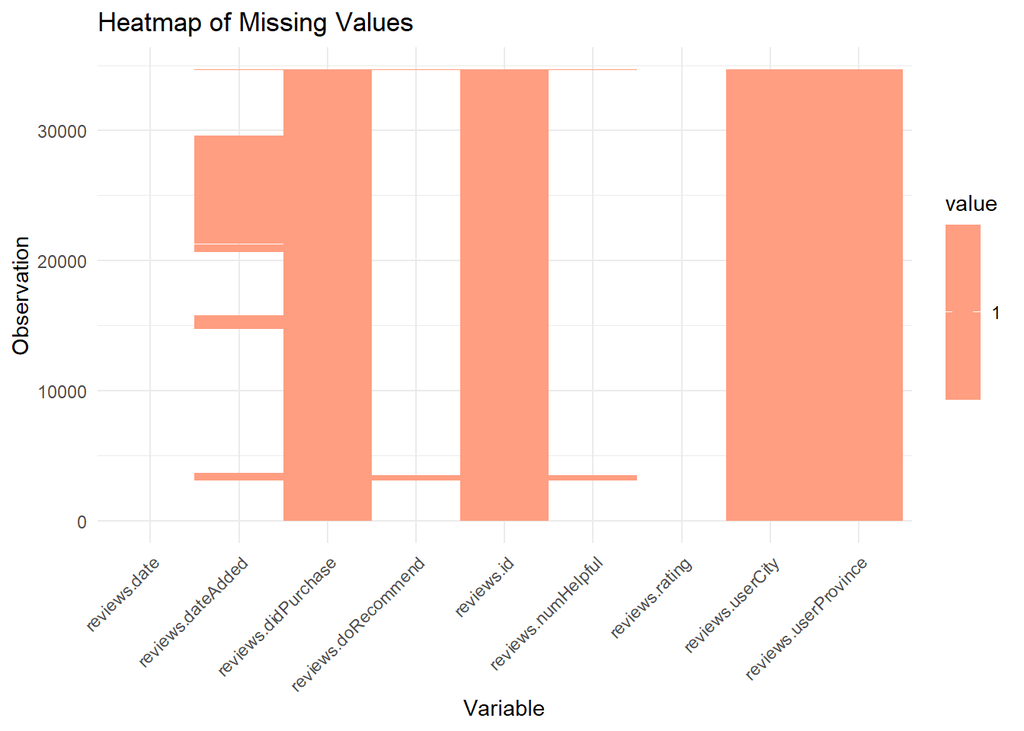

```r
# Create a matrix of missing values
missing_matrix <- is.na(df1)

# Convert matrix to data frame
missing_df <- as.data.frame(missing_matrix)

# Reshape data to long format
missing_long <- missing_df %>%
  mutate(row = 1:nrow(.)) %>%
  gather(variable, value, -row) %>%
  filter(value == TRUE) %>%
  mutate(value = 1)

# Plot heatmap
ggplot(missing_long, aes(variable, row, fill = value)) +
  geom_tile() +
  scale_fill_gradient(low = "white", high = "red", na.value = "white") +
  theme_minimal() +
  labs(title = "Heatmap of Missing Values", x = "Variable", y = "Observation") +
  theme(axis.text.x = element_text(angle = 45, vjust = 1, hjust = 1))
```

#### Finding out missing values in each coloumn/observation/feature.

```r
missing_values <- sapply(df1, function(x) sum(is.na(x)))
missing_df <- data.frame(Column = names(missing_values), `Missing Values` = missing_values, row.names = NULL)

cat("Number of missing values per column:\n")
```

```
## Number of missing values per column:
```

```r
knitr::kable(missing_df, format = "markdown", row.names = FALSE)
```

| Column | Missing.Values |
| --- | --- |
| id | 0 |
| name | 0 |
| asins | 0 |
| brand | 0 |
| categories | 0 |
| keys | 0 |
| manufacturer | 0 |
| reviews.date | 39 |
| reviews.dateAdded | 10621 |
| reviews.dateSeen | 0 |
| reviews.didPurchase | 34659 |
| reviews.doRecommend | 594 |
| reviews.id | 34659 |
| reviews.numHelpful | 529 |
| reviews.rating | 33 |
| reviews.sourceURLs | 0 |
| reviews.text | 0 |
| reviews.title | 0 |
| reviews.userCity | 34660 |
| reviews.userProvince | 34660 |
| reviews.username | 0 |

#### Dropping off the 4 variables(“reviews.didPurchase”, “reviews.id”, “reviews.userCity”,“reviews.userProvince”) from the dataset as their data is completely missing.

```r
columns_to_drop <- c("reviews.didPurchase", "reviews.id", "reviews.userCity","reviews.userProvince")
df1_clean <- subset(df1, select = -c(reviews.didPurchase, reviews.id, reviews.userCity,reviews.userProvince))
```

#### No. of missing values after removing 4 empty features

```r
sum(is.na(df1_clean))
```

```
## [1] 11816
```

##### Removing rows of 4 variables (“reviews.date”,“reviews.doRecommend”, “reviews.numHelpful”, “reviews.rating”) that have less than 2% of missing values

```r
df1_clean1 <- subset(df1_clean, !is.na(df1_clean$reviews.date) & !is.na(df1_clean$reviews.doRecommend) & !is.na(df1_clean$reviews.numHelpful) & !is.na(df1_clean$reviews.rating))
```

#### Checking number of rows before and after removing rows with missing values

```r
cat("Number of rows of original dataset df1:", nrow(df1), "\n")
```

```
## Number of rows of original dataset df1: 34660
```

```r
cat("Number of rows after dropping var's with no data df1_clean :", nrow(df1_clean), "\n")
```

```
## Number of rows after dropping var's with no data df1_clean : 34660
```

```r
cat("Number of rows after removing rows of var's that have less than 2% missing values df1_clean1:", nrow(df1_clean1), "\n")
```

```
## Number of rows after removing rows of var's that have less than 2% missing values df1_clean1: 34064
```

#### No. of rows in a cleaned dataset “df1_clean1” are 34,064.

```r
summary(df1_clean1)
```

```
##       id                name              asins
##  Length:34064       Length:34064       Length:34064
##  Class :character   Class :character   Class :character
##  Mode  :character   Mode  :character   Mode  :character
##
##
##
##
##                           brand        categories            keys
##  Amazon                      :28124   Length:34064       Length:34064
##  Amazon Coco T               :    0   Class :character   Class :character
##  Amazon Digital Services Inc.:    0   Mode  :character   Mode  :character
##  Amazon Echo                 :  633
##  Amazon Fire                 :  255
##  Amazon Fire Tv              : 5052
##
##                        manufacturer    reviews.date        reviews.dateAdded
##  Amazon                      :34064   Min.   :2014-10-24   Min.   :2017-03-06
##  Amazon Digital Services, Inc:    0   1st Qu.:2016-06-10   1st Qu.:2017-05-21
##                                       Median :2016-12-23   Median :2017-05-21
##                                       Mean   :2016-10-29   Mean   :2017-07-02
##                                       3rd Qu.:2017-03-06   3rd Qu.:2017-09-05
##                                       Max.   :2018-04-18   Max.   :2017-12-11
##                                                            NA's   :10031
##  reviews.dateSeen   reviews.doRecommend reviews.numHelpful reviews.rating
##  Length:34064       Mode :logical       Min.   :  0.0000   Min.   :1.00
##  Class :character   FALSE:1384          1st Qu.:  0.0000   1st Qu.:4.00
##  Mode  :character   TRUE :32680         Median :  0.0000   Median :5.00
##                                         Mean   :  0.2585   Mean   :4.59
##                                         3rd Qu.:  0.0000   3rd Qu.:5.00
##                                         Max.   :109.0000   Max.   :5.00
##
##  reviews.sourceURLs reviews.text       reviews.title      reviews.username
##  Length:34064       Length:34064       Length:34064       Length:34064
##  Class :character   Class :character   Class :character   Class :character
##  Mode  :character   Mode  :character   Mode  :character   Mode  :character
##
##
##
##
```

## Initial Data Exploration

1. Distribution of review ratings:

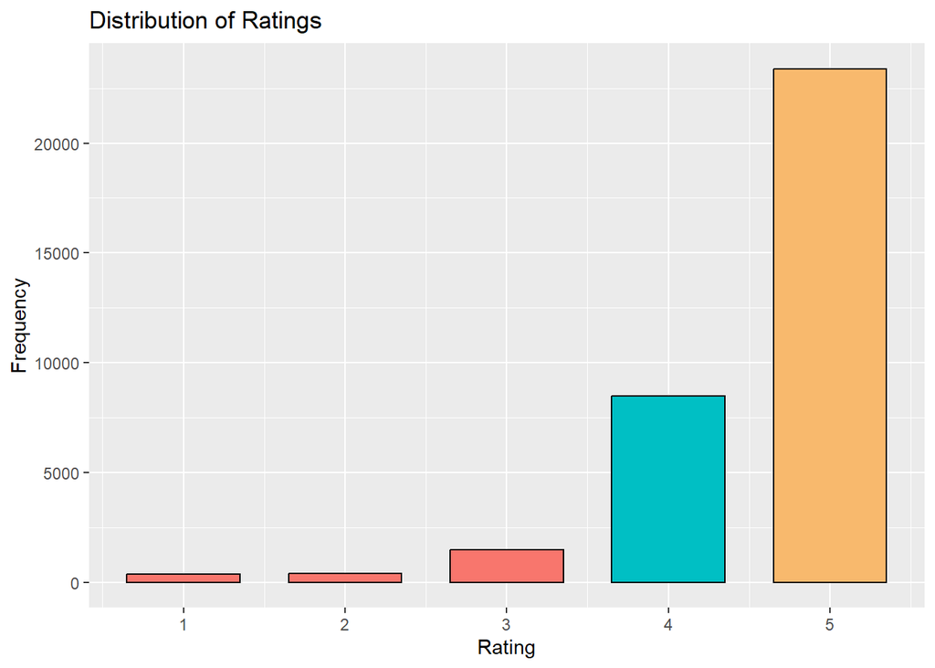

```r
rating_colors <- function(rating) {
  if (rating == 5) {
    return("#f8b96d")
  } else if (rating == 4) {
    return("#00BFC4")
  } else {
    return("#F8766D")
  }
}

# Create a new column in the data frame with custom colors based on rating values
df1_clean1$rating_color <- sapply(df1_clean1$reviews.rating, rating_colors)

# Bar plot with custom colors
ggplot(df1_clean1, aes(x = reviews.rating, fill = rating_color)) +
  geom_bar(color = "black", width = 0.7) +
  scale_fill_identity() +
  labs(title = "Distribution of Ratings", x = "Rating", y = "Frequency") +
  theme(legend.position = "none")
```

The visual represents the distribution of 34,064 customer ratings, with a rating scale from 1 (least favorable) to 5 (most favorable). A clear majority of customers have a positive perception of the products, as evidenced by the high percentage of ratings at the top end of the scale. Specifically, 68.7% of customers assigned the highest rating of 5, while 24.9% opted for a rating of 4. On the other hand, lower ratings constitute a small portion of the total, with 4.3% at 3, 1.1% at 2, and only 1% at the lowest rating of 1. This distribution highlights the overall customer satisfaction with the products, as most ratings are concentrated at 4 and 5.

2. Distribution of Ratings by Recommended Status:

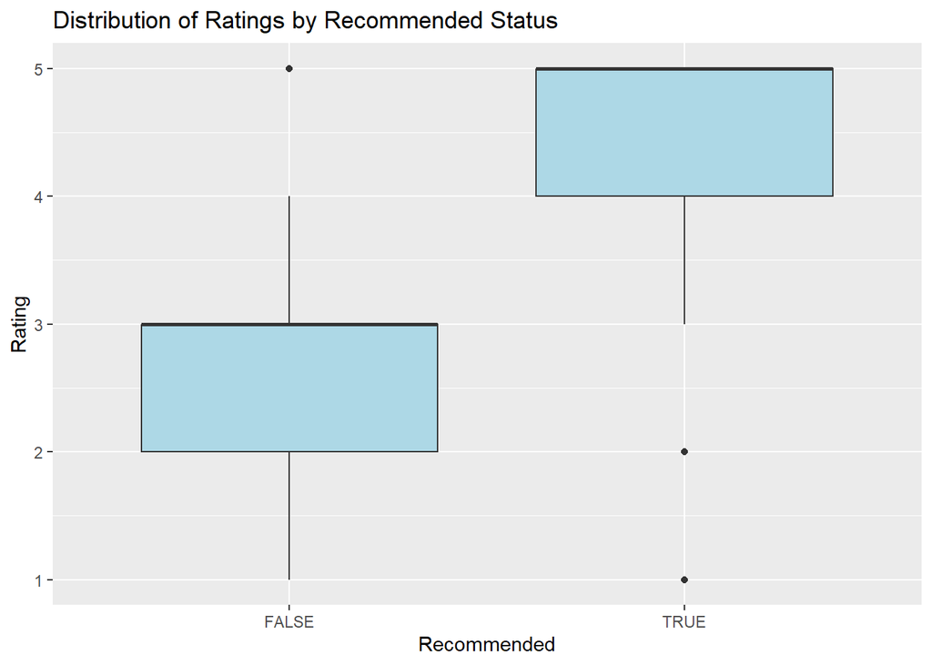

```r
# Box plot
ggplot(df1_clean1, aes(x = as.factor(reviews.doRecommend), y = reviews.rating)) +
  geom_boxplot(fill = "lightblue") +
  labs(title = "Distribution of Ratings by Recommended Status", x = "Recommended", y = "Rating")
```

The Distribution of Ratings by Recommended Status box plot reveals:

1. “Recommended” group (True) has an IQR between 4 and 5, indicating high ratings from those who recommended the product.
2. “Not Recommended” group (False) has an IQR between 2 and 3, representing low ratings from those who didn’t recommend the product.
3. The visual highlights a positive correlation between ratings and recommended status, suggesting that the ratings are genuine and reflect customers’ true opinions about the product.

```r
names(df1_clean1)
```

```
##  [1] "id"                  "name"                "asins"
##  [4] "brand"               "categories"          "keys"
##  [7] "manufacturer"        "reviews.date"        "reviews.dateAdded"
## [10] "reviews.dateSeen"    "reviews.doRecommend" "reviews.numHelpful"
## [13] "reviews.rating"      "reviews.sourceURLs"  "reviews.text"
## [16] "reviews.title"       "reviews.username"    "rating_color"
```

3. Number of reviews per brand:

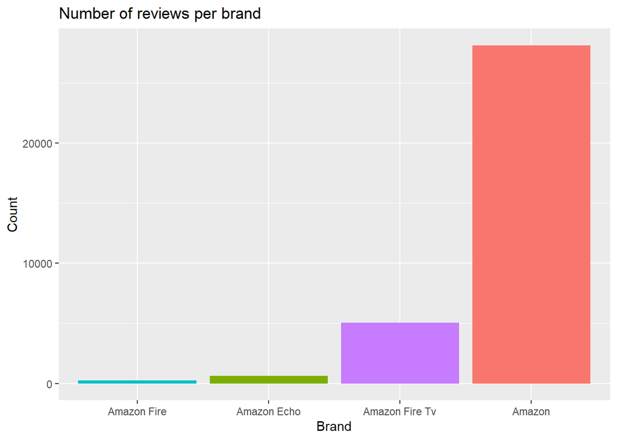

```r
# Bar chart
df1_clean1 %>%
  group_by(brand) %>%
  summarize(n = n()) %>%
  top_n(6, n) %>%
  ggplot(aes(x = reorder(brand, n), y = n, fill = brand)) +
  geom_bar(stat = "identity") +
  labs(title = "Number of reviews per brand", x = "Brand", y = "Count") +
  theme(legend.position = "none")
```

The visual shows the distribution of reviews across different brands.

1. The majority of reviews (82.6%) were for ‘Amazon’ products, with 28,124 reviews, indicating a strong interest in the Amazon brand among consumers.
2. The second-highest number of reviews (14.8%) was for ‘Amazon Fire TV,’ which had 5,052 reviews, showing that it is also a popular product line.
3. ‘Amazon Echo’ and ‘Amazon Fire’ received comparatively fewer reviews, with only 1.9% (633 reviews) and 0.7% (255 reviews) of the total, respectively. This suggests that these brands might be less popular or have a smaller customer base compared to Amazon and Amazon Fire TV products.
4. Proportion of recommended products by brand:

```r
recommendations_by_brand <- df1_clean1 %>%
  group_by(brand, reviews.doRecommend) %>%
  summarize(count = n()) %>%
  mutate(percentage = count / sum(count))
```

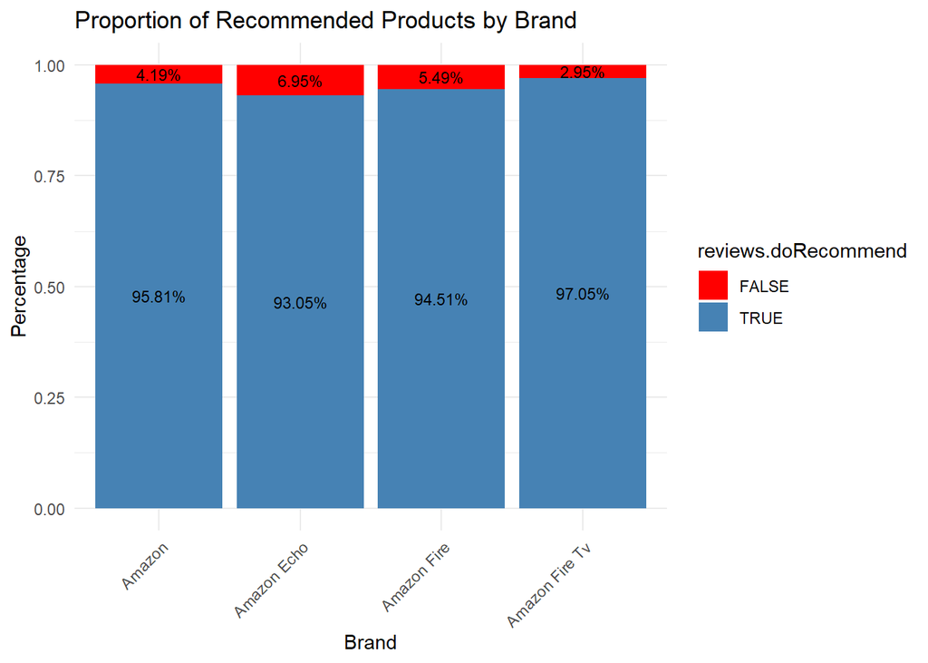

```r
ggplot(recommendations_by_brand, aes(x = brand, y = percentage, fill = reviews.doRecommend)) +
  geom_bar(stat = "identity", position = "stack") +
  geom_text(aes(label = paste0(round(percentage*100,2),"%")),
            position = position_stack(vjust = 0.5), color = "black", size = 3) +
  labs(title = "Proportion of Recommended Products by Brand",
       x = "Brand",
       y = "Percentage") +
  theme_minimal() +
  theme(axis.text.x = element_text(angle = 45, hjust = 1)) +
  scale_fill_manual(values = c("red", "steelblue"))
```

On the other hand, the visual also reveals that ‘Amazon Echo’ has the highest proportion of dissatisfied customers, with a not recommended rate of 6.96%. This is followed by ‘Amazon Fire’ at 5.5%, ‘Amazon’ at 4.19%, and ‘Amazon Fire TV’ at 2.95%. The data suggests that the company may need to focus on improving customer satisfaction for the ‘Amazon Echo’ and ‘Amazon Fire’ product lines, as they have the highest proportion of not recommended reviews.

5. Review Ratings by Brand:

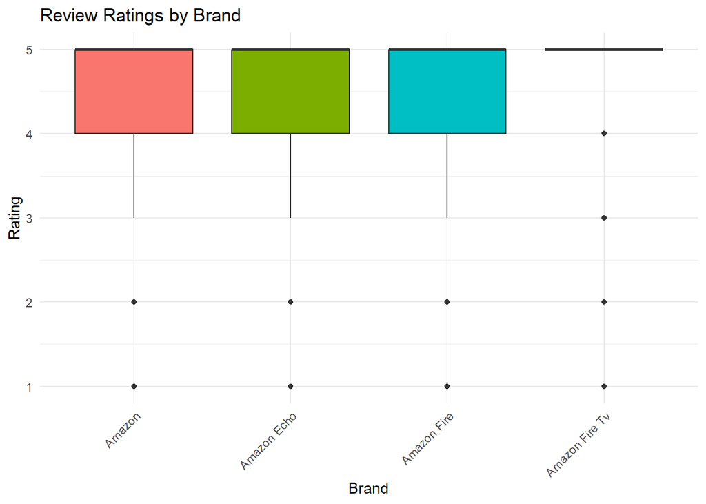

```r
ggplot(df1_clean1, aes(x = brand, y = reviews.rating, fill = brand)) +
  geom_boxplot() +
  labs(title = "Review Ratings by Brand",
       x = "Brand",
       y = "Rating") +
  theme_minimal() +
  theme(axis.text.x = element_text(angle = 45, hjust = 1)) +
  guides(fill = FALSE)
```

The box plot visualization of review ratings by brand reveals the following insights:

1. ‘Amazon’, ‘Amazon Echo’, and ‘Amazon Fire’ have IQRs between 4 and 5, indicating mostly positive ratings. Outliers at ratings 1 and 2 represent a few dissatisfied customers.
2. ‘Amazon Fire TV’ shows a compact box plot with most ratings at 5, signifying high customer satisfaction. Ratings 4, 3, 2, and 1 appear as outliers, representing a small number of less satisfied customers.

This visualization helps identify each brand’s performance in terms of customer satisfaction and highlights areas for potential improvement.

6. Time series plot of review ratings:

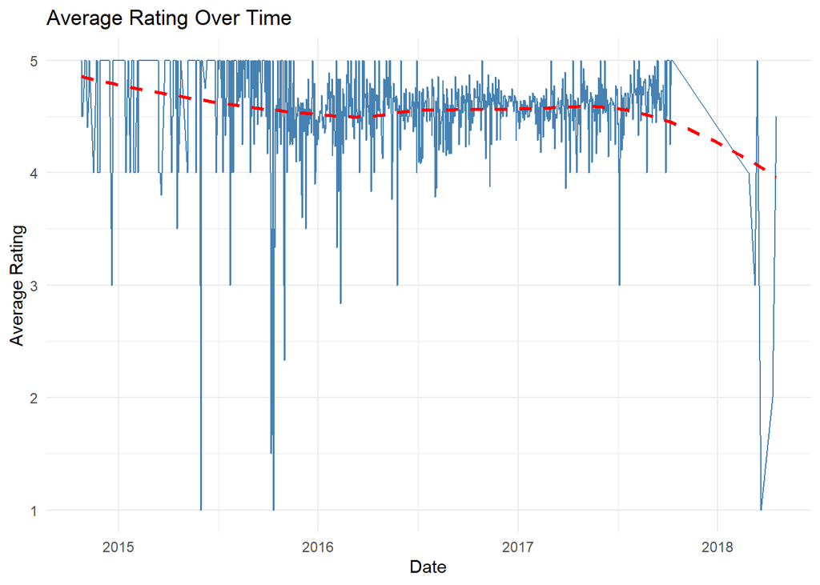

```r
df1_clean1$reviews.date <- as.Date(df1_clean1$reviews.date)

rating_time_series <- df1_clean1 %>%
  group_by(reviews.date) %>%
  summarize(avg_rating = mean(reviews.rating, na.rm = TRUE))

ggplot(rating_time_series, aes(x = reviews.date, y = avg_rating)) +
  geom_line(color = "steelblue") +
  geom_smooth(method = "loess", se = FALSE, linetype = "dashed", color = "red") +
  labs(title = "Average Rating Over Time",
       x = "Date",
       y = "Average Rating") +
  theme_minimal()
```

The time series plot of review ratings provides insights into the trends and changes in customer satisfaction over time. From the visualization, we can observe the following:

1. Between 2014-10-24 and the end of 2017, the average rating mostly fluctuated between 4 and 5, indicating that the customers generally had a positive experience with the products. There were only a few instances where the average rating dipped to around 3, and even fewer instances where it reached 1 or 2.
2. As we enter 2018, there appears to be a structural break in the pattern, with the smoothing curve (red dashed line) indicating a downward trend in the average rating. This suggests that in 2018, there was an increase in the number of lower ratings (1 or 2) compared to higher ratings (4 and 5).

This time series plot highlights the need to investigate further into the possible causes of the decline in customer satisfaction in 2018. Understanding the factors behind this trend can help improve the products and marketing strategies to enhance customer satisfaction in the future.

```r
min(df1_clean1$reviews.date)
```

```
## [1] "2014-10-24"
```

```r
max(df1_clean1$reviews.date)
```

```
## [1] "2018-04-18"
```

7. Relationship Between Helpful Votes and Rating

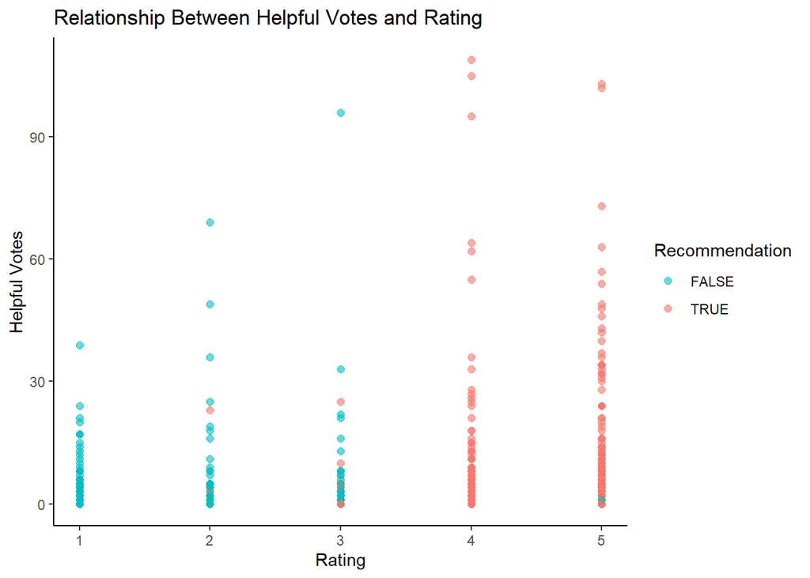

```r
# Scatter plot
ggplot(df1_clean1, aes(x = reviews.rating, y = reviews.numHelpful, color = as.factor(reviews.doRecommend))) +
  geom_point(alpha = 0.6, size = 2) +
  scale_color_manual(values = c("#00BFC4", "#F8766D")) +
  labs(title = "Relationship Between Helpful Votes and Rating", x = "Rating", y = "Helpful Votes", color = "Recommendation") +
  theme_classic()
```

Based on the scatter plot, we can observe the following:

1. Higher ratings (4-5 stars) are associated with positive recommendations and generally have a higher number of helpful votes, indicating that other customers find these reviews useful.
2. Lower ratings (1-3 stars) correspond to negative recommendations and usually have fewer helpful votes, suggesting that these reviews are considered less useful by other customers.
3. There are some outliers in the plot, which may require further investigation to understand any discrepancies between ratings and helpful votes.
4. Distribution of helpful reviews:

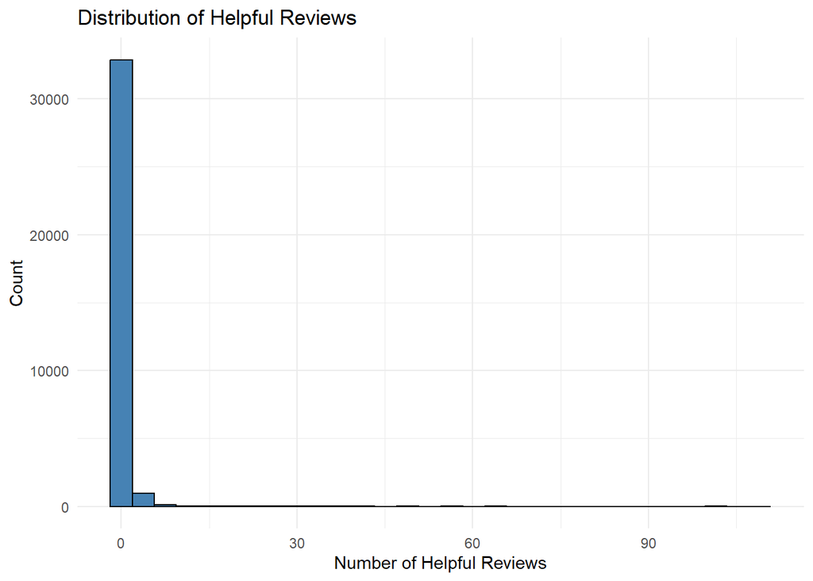

```r
ggplot(df1_clean1, aes(x = reviews.numHelpful)) +
  geom_histogram(bins = 30, fill = "steelblue", color = "black") +
  labs(title = "Distribution of Helpful Reviews",
       x = "Number of Helpful Reviews",
       y = "Count") +
  theme_minimal()
```

9.Proportion of recommendations:

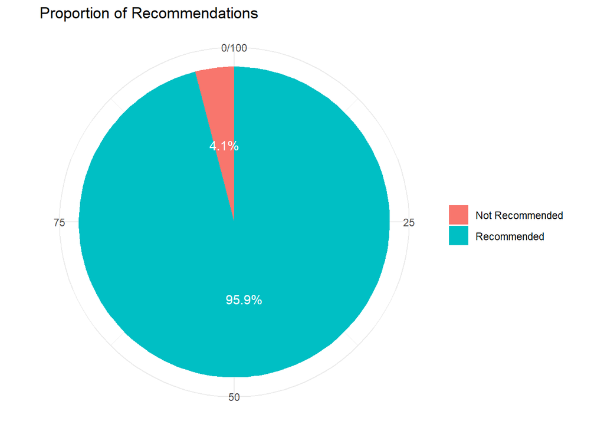

```r
recommendation_prop <- df1_clean1 %>%
  group_by(reviews.doRecommend) %>%
  summarize(count = n()) %>%
  mutate(percentage = count / sum(count) * 100)

ggplot(recommendation_prop, aes(x = "", y = percentage, fill = factor(reviews.doRecommend), label = paste0(round(percentage, 1), "%"))) +
  geom_bar(width = 1, stat = "identity") +
  geom_text(position = position_stack(vjust = 0.5), color = "white") +
  coord_polar("y", start = 0) +
  labs(title = "Proportion of Recommendations",
       x = NULL,
       y = NULL) +
  theme_minimal() +
  theme(legend.title = element_blank(),
        legend.position = "right") +
  scale_fill_discrete(labels = c("Not Recommended", "Recommended"))
```

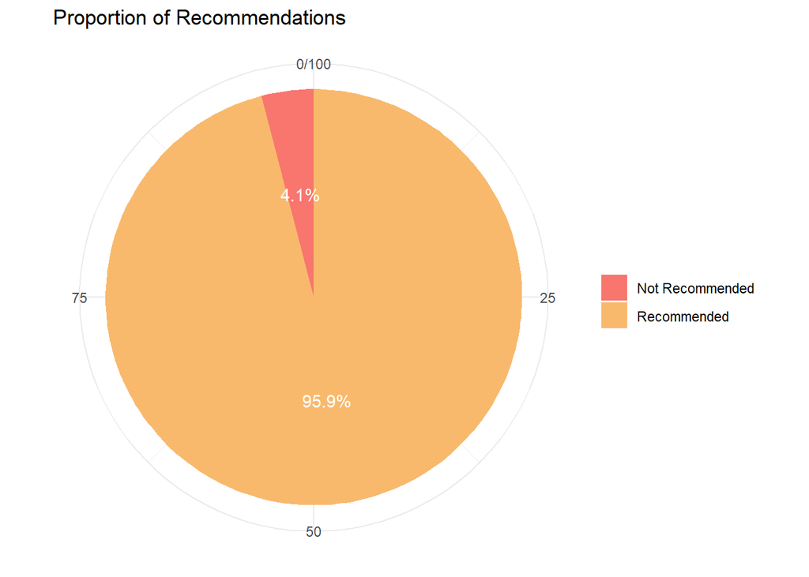

```r
ggplot(recommendation_prop, aes(x = "", y = percentage, fill = factor(reviews.doRecommend), label = paste0(round(percentage, 1), "%"))) +
  geom_bar(width = 1, stat = "identity") +
  geom_text(position = position_stack(vjust = 0.5), color = "white") +
  coord_polar("y", start = 0) +
  labs(title = "Proportion of Recommendations",
       x = NULL,
       y = NULL) +
  theme_minimal() +
  theme(legend.title = element_blank(),
        legend.position = "right") +
  scale_fill_manual(values = c("#F8766D", "#f8b96d"),
                    labels = c("Not Recommended", "Recommended"))
```

The pie chart displays the proportion of recommended and not recommended products based on customer reviews. It shows that 95.9% of the reviews are positive, with customers recommending the products, while only 4.1% of the reviews are not recommending the products. This indicates that the majority of customers have had a favorable experience with the products, suggesting overall high satisfaction levels.

10.Word cloud for most common words in reviews:

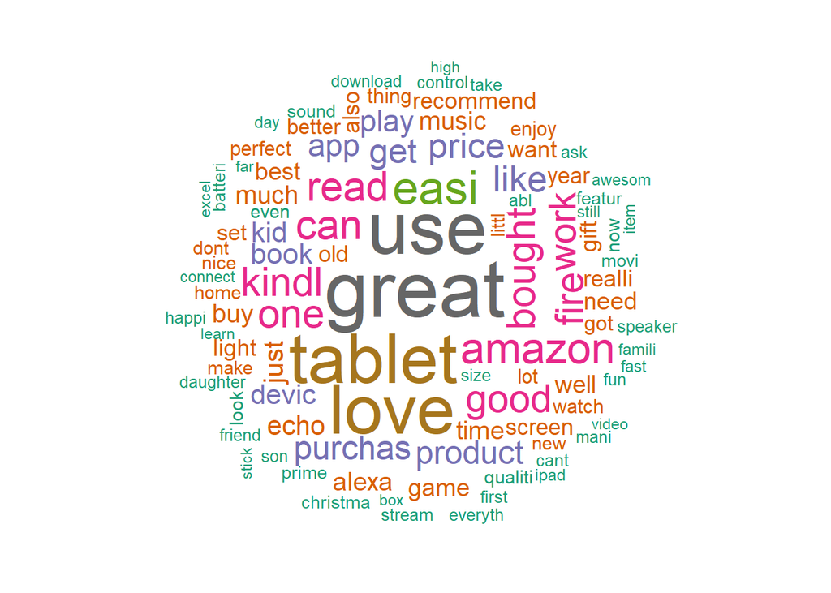

```r
# Create a corpus from the 'reviews.text' column
reviews_corpus <- VCorpus(VectorSource(df1_clean1$reviews.text))

# Pre-process the text data
reviews_corpus <- tm_map(reviews_corpus, content_transformer(tolower))
reviews_corpus <- tm_map(reviews_corpus, removeNumbers)
reviews_corpus <- tm_map(reviews_corpus, removePunctuation)
reviews_corpus <- tm_map(reviews_corpus, stripWhitespace)
reviews_corpus <- tm_map(reviews_corpus, removeWords, stopwords("english"))
reviews_corpus <- tm_map(reviews_corpus, stemDocument)

# Create a document-term matrix
dtm <- DocumentTermMatrix(reviews_corpus)

# Calculate word frequencies
word_freqs <- colSums(as.matrix(dtm))

# Sort word frequencies in decreasing order
word_freqs_sorted <- sort(word_freqs, decreasing = TRUE)

# Create a word cloud
wordcloud(words = names(word_freqs_sorted), freq = word_freqs_sorted, min.freq = 50,
          max.words = 100, random.order = FALSE, colors = brewer.pal(8, "Dark2"))
```

The word cloud provides a visual representation of the most frequently mentioned words in the reviews. The size of each word represents its frequency in the dataset. From this visualization, we can observe the following:

1. The words **‘great’** and **‘use’** are the most frequently mentioned, indicating that many customers find the product to be of high quality and useful.
2. The words ‘tablet’ and ‘love’ are the second most common, suggesting that customers are expressing their appreciation for the tablets.
3. Other common words include ‘amazon’, ‘bought’, ‘good’, ‘read’, ‘work’, ‘kindle’, and ‘one’. These words are smaller in size compared to the top two, but still significant in frequency, highlighting various aspects of the products, such as the brand, usage, and purchasing experiences.

This word cloud helps us gain a quick understanding of the customers’ opinions and the key themes present in the reviews.

```r
head(df1$reviews.dateAdded)
```

```
## [1] "2017-07-03" "2017-07-03" "2017-07-03" "2017-07-03" "2017-07-03"
## [6] "2017-07-03"
```

#### 11. Distribution of rating over Days of the week and time of the day

```r
# Create a copy of the dataset
df1_copy <- df1

# Convert the 'reviews.dateAdded' column in the copied dataset to a POSIXct type
df1_copy$reviews.dateAdded <- as.POSIXct(df1_copy$reviews.dateAdded, format = "%Y-%m-%dT%H:%M:%S")

# Extract the time information from the 'reviews.dateAdded' column in the copied dataset
df1_copy$time <- format(df1_copy$reviews.dateAdded, format = "%H:%M:%S")

# Create a new dataset with the extracted time information
time_data <- data.frame(time = df1_copy$time)
```

```r
# Add the 'weekday' column to df1_copy
df1_copy$weekday <- weekdays(df1_copy$reviews.dateAdded)

df1_copy$hour_12 <- format(df1_copy$reviews.dateAdded, format = "%I %p")
df1_aggregated <- df1_copy %>%
  group_by(weekday, hour_12) %>%
  summarize(avg_rating = mean(reviews.rating, na.rm = TRUE)) %>%
  ungroup()
```

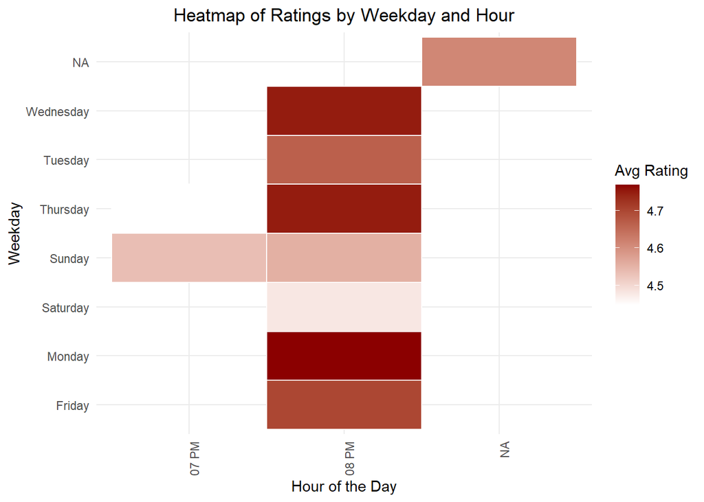

```r
ggplot(df1_aggregated, aes(x = hour_12, y = weekday, fill = avg_rating)) +
  geom_tile(color = "white", size = 0.5) +
  scale_fill_gradientn(colors = c("white", "darkred")) +
  labs(title = "Heatmap of Ratings by Weekday and Hour",
       x = "Hour of the Day",
       y = "Weekday",
       fill = "Avg Rating") +
  theme_minimal() +
  theme(axis.text.x = element_text(angle = 90, hjust = 1),
        plot.title = element_text(hjust = 0.5))
```

#### The heatmap displays average customer ratings by weekdays and hours, revealing that most ratings occur around 8 PM, with Sundays also having a notable amount at 7 PM. Average ratings range from 4.48 to 4.77, with Mondays and Wednesdays having the highest ratings. Sundays have a slightly lower average of 4.55. This information helps businesses understand customer behavior and preferences across the week..

#### Avg Rating by day.

```r
# Calculate average rating by weekday and sort by average rating
avg_rating_by_weekday <- df1_copy %>%
  group_by(weekday) %>%
  summarise(avg_rating = mean(reviews.rating, na.rm = TRUE)) %>%
  arrange(desc(avg_rating))

# Create a custom color scale
color_scale <- colorRampPalette(c("lightcoral", "darkred"), space = "Lab")

# Create a table with a color scale for the average ratings
formattable(avg_rating_by_weekday, list(
  avg_rating = formatter("span",
                         style = x ~ style(
                           display = "block",
                           padding = "0 4px",
                           "border-radius" = "4px",
                           "color" = "white",
                           "background-color" = csscolor(
                             color_scale(100)[findInterval(x, seq(min(avg_rating_by_weekday$avg_rating), max(avg_rating_by_weekday$avg_rating), length.out = 100))])
                         ),
                         x ~ round(x, 2))
))
```

| weekday | avg_rating |
| --- | --- |
| Monday | 4.77 |
| Wednesday | 4.75 |
| Friday | 4.7 |
| Tuesday | 4.67 |
| NA | 4.61 |
| Sunday | 4.55 |
| Thursday | 4.51 |
| Saturday | 4.48 |

#### Finding out unique values in variables ‘id’, ‘name’ & ‘categories’

```r
unique_counts <- df1_clean1 %>%
  summarise(id_count = n_distinct(id),
            name_count = n_distinct(name),
            categories_count = n_distinct(categories))

unique_counts
```

```
##   id_count name_count categories_count
## 1       24         45               23
```

```r
kable(unique_counts, format = "markdown")
```

| id_count | name_count | categories_count |
| --- | --- | --- |
| 24 | 45 | 23 |

#### Displaying unique categories in the variable ‘categories’

```r
# Get unique categories
unique_categories <- unique(df1_clean1$categories)
# Display unique categories
kable(unique_categories)
```

| x |
| --- |
| Electronics,iPad & Tablets,All Tablets,Fire Tablets,Tablets,Computers & Tablets |
| eBook Readers,Kindle E-readers,Computers & Tablets,E-Readers & Accessories,E-Readers |
| Tablets,Fire Tablets,Electronics,Computers,Computer Components,Hard Drives & Storage,Computers & Tablets,All Tablets |
| Tablets,Fire Tablets,Computers & Tablets,All Tablets |
| Electronics,iPad & Tablets,All Tablets,Computers/Tablets & Networking,Tablets & eBook Readers,Computers & Tablets,E-Readers & Accessories,E-Readers,Used:Computers Accessories,Used:Tablets,Computers,iP… |
| Fire Tablets,Tablets,Computers & Tablets,All Tablets,Electronics, Tech Toys, Movies, Music,Electronics,iPad & Tablets,Android Tablets,Frys |
| Kindle E-readers,Electronics Features,Computers & Tablets,E-Readers & Accessories,E-Readers,eBook Readers |
| Computers & Tablets,E-Readers & Accessories,eBook Readers,Kindle E-readers |
| Fire Tablets,Tablets,Computers & Tablets,All Tablets |
| Computers/Tablets & Networking,Tablets & eBook Readers,Computers & Tablets,Tablets,All Tablets |
| Walmart for Business,Office Electronics,Tablets,Office,Electronics,iPad & Tablets,Windows Tablets,All Windows Tablets,Computers & Tablets,E-Readers & Accessories,E-Readers,eBook Readers,Kindle E-reade… |
| Walmart for Business,Office Electronics,Tablets,Electronics,iPad & Tablets,All Tablets,Computers & Tablets,E-Readers & Accessories,Kindle E-readers,Electronics Features,eBook Readers,See more Amazon K… |
| Electronics,Computers,Computer Accessories,Cases & Bags,Fire Tablets,Electronics Features,Tablets,Computers & Tablets,Kids’ Tablets,Electronics, Tech Toys, Movies, Music,iPad & Tablets,Top Rated |
| Electronics,iPad & Tablets,All Tablets,Computers & Tablets,Tablets,eBook Readers |
| Fire Tablets,Tablets,Computers & Tablets,All Tablets,Computers/Tablets & Networking,Tablets & eBook Readers |
| Computers & Tablets,Tablets,All Tablets,Computers/Tablets & Networking,Tablets & eBook Readers,Fire Tablets,Frys |
| Electronics Features,Fire Tablets,Computers & Tablets,Tablets,All Tablets,Computers/Tablets & Networking,Tablets & eBook Readers |
| Stereos,Remote Controls,Amazon Echo,Audio Docks & Mini Speakers,Amazon Echo Accessories,Kitchen & Dining Features,Speaker Systems,Electronics,TVs Entertainment,Clearance,Smart Hubs & Wireless Routers,… |
| Fire Tablets,Tablets,Computers & Tablets,All Tablets,Frys |
| Chargers & Adapters,Computers & Accessories,Tablet & E-Reader Accessories,Amazon Devices & Accessories,Fire Tablet Accessories,Electronics,Power Adapters & Cables,Cell Phones,Amazon Device Accessories… |
| Electronics,Tablets & E-Readers,Tablets,Back To College,College Electronics,College Ipads & Tablets,Featured Brands,Amazon Devices,Electronics Deals,Computers & Tablets,All Tablets,Electronics Feature… |
| Featured Brands,Electronics,Amazon Devices,Home,Home Improvement,Home Safety & Security,Home Security,Alarms & Sensors,Smart Home & Home Automation Devices,Mobile,Mobile Speakers,Mobile Bluetooth Spea… |
| Back To College,College Electronics,College Tvs & Home Theater,Electronics,Tvs & Home Theater,Streaming Devices,Featured Brands,Amazon Devices,Holiday Shop,Ways To Shop,TV & Home Theater,Streaming Med… |

```r
dim(df1)
```

```
## [1] 34660    21
```

```r
dim(df1_clean1)
```

```
## [1] 34064    18
```

### Defining category groupings. Making 5 groups/ variables

1. Tablets & E-Readers : Tblts
2. Amazon Devices : AmzDvcs
3. Accessories : Accz
4. Electronics : Elec
5. office & Business : OffnBuss

```r
Tblts <- c("Electronics,iPad & Tablets,All Tablets,Fire Tablets,Tablets,Computers & Tablets",
            "Tablets,Fire Tablets,Electronics,Computers,Computer Components,Hard Drives & Storage,Computers & Tablets,All Tablets",
            "Tablets,Fire Tablets,Computers & Tablets,All Tablets",
            "Electronics,iPad & Tablets,All Tablets,Computers/Tablets & Networking,Tablets & eBook Readers,Computers & Tablets,E-Readers & Accessories,E-Readers,Used:Computers Accessories,Used:Tablets,Computers,iPads Tablets,Kindle E-readers,Electronics Features",
            "Fire Tablets,Tablets,Computers & Tablets,All Tablets,Electronics, Tech Toys, Movies, Music,Electronics,iPad & Tablets,Android Tablets,Frys",
            "Fire Tablets,Tablets,Computers & Tablets,All Tablets",
            "Computers/Tablets & Networking,Tablets & eBook Readers,Computers & Tablets,Tablets,All Tablets",
            "Electronics,iPad & Tablets,All Tablets,Computers & Tablets,Tablets,eBook Readers",
            "Fire Tablets,Tablets,Computers & Tablets,All Tablets,Computers/Tablets & Networking,Tablets & eBook Readers",
            "Computers & Tablets,Tablets,All Tablets,Computers/Tablets & Networking,Tablets & eBook Readers,Fire Tablets,Frys",
            "Fire Tablets,Tablets,Computers & Tablets,All Tablets,Frys")

AmzDvcs <- c("eBook Readers,Kindle E-readers,Computers & Tablets,E-Readers & Accessories,E-Readers",
            "Kindle E-readers,Electronics Features,Computers & Tablets,E-Readers & Accessories,E-Readers,eBook Readers",
            "Computers & Tablets,E-Readers & Accessories,eBook Readers,Kindle E-readers",
            "Featured Brands,Electronics,Amazon Devices,Home,Home Improvement,Home Safety & Security,Home Security,Alarms & Sensors,Smart Home & Home Automation Devices,Mobile,Mobile Speakers,Mobile Bluetooth Speakers,Smart Hubs & Wireless Routers,Smart Hubs,Home, Garage & Office,Smart Home,Voice Assistants,Smart Home & Connected Living,Amazon Tap,Portable Audio,MP3 Accessories,Speakers,Amazon Echo,Electronics Features,TVs & Electronics,Portable Audio & Electronics,MP3 Player Accessories,Home Theater & Audio,Kindle Store,Frys,Electronic Components,Home Automation,Electronics, Tech Toys, Movies, Music,Audio,Bluetooth Speakers")

Accz <- c("Stereos,Remote Controls,Amazon Echo,Audio Docks & Mini Speakers,Amazon Echo Accessories,Kitchen & Dining Features,Speaker Systems,Electronics,TVs Entertainment,Clearance,Smart Hubs & Wireless Routers,Featured Brands,Wireless Speakers,Smart Home & Connected Living,Home Security,Kindle Store,Home Automation,Home, Garage & Office,Home,Voice-Enabled Smart Assistants,Virtual Assistant Speakers,Portable Audio & Headphones,Electronics Features,Amazon Device Accessories,iPod, Audio Player Accessories,Home & Furniture Clearance,Consumer Electronics,Smart Home,Surveillance,Home Improvement,Smart Home & Home Automation Devices,Smart Hubs,Home Safety & Security,Voice Assistants,Alarms & Sensors,Amazon Devices,Audio,Holiday Shop",
            "Chargers & Adapters,Computers & Accessories,Tablet & E-Reader Accessories,Amazon Devices & Accessories,Fire Tablet Accessories,Electronics,Power Adapters & Cables,Cell Phones,Amazon Device Accessories,Cell Phone Accessories,Cell Phone Batteries & Power,Tablet Accessories,Featured Brands,Kindle Fire (2nd Generation) Accessories,Kindle Store,Home Improvement,Fire (5th Generation) Accessories,Electrical,Amazon Devices,Home,Tablets & E-Readers,Cables & Chargers")

Elec <- c("Electronics,Computers,Computer Accessories,Cases & Bags,Fire Tablets,Electronics Features,Tablets,Computers & Tablets,Kids’ Tablets,Electronics, Tech Toys, Movies, Music,iPad & Tablets,Top Rated",
            "Electronics Features,Fire Tablets,Computers & Tablets,Tablets,All Tablets,Computers/Tablets & Networking,Tablets & eBook Readers",
            "Electronics,Tablets & E-Readers,Tablets,Back To College,College Electronics,College Ipads & Tablets,Featured Brands,Amazon Devices,Electronics Deals,Computers & Tablets,All Tablets,Electronics Features,eBook Readers",
            "Back To College,College Electronics,College Tvs & Home Theater,Electronics,Tvs & Home Theater,Streaming Devices,Featured Brands,Amazon Devices,Holiday Shop,Ways To Shop,TV & Home Theater,Streaming Media Players,All Streaming Media Players,TVs Entertainment,Video Games,Kindle Store,Electronics Features,Kids & Family,Fire TV")

OffnBuss <- c("Walmart for Business,Office Electronics,Tablets,Office,Electronics,iPad & Tablets,Windows Tablets,All Windows Tablets,Computers & Tablets,E-Readers & Accessories,E-Readers,eBook Readers,Kindle E-readers,Computers/Tablets & Networking,Tablets & eBook Readers,Electronics Features,Books & Magazines,Book Accessories,eReaders,TVs & Electronics,Computers & Laptops,Tablets & eReaders",
            "Walmart for Business,Office Electronics,Tablets,Electronics,iPad & Tablets,All Tablets,Computers & Tablets,E-Readers & Accessories,Kindle E-readers,Electronics Features,eBook Readers,See more Amazon Kindle Voyage (Wi-Fi),See more Amazon Kindle Voyage 4GB, Wi-Fi 3G (Unlocked…")
```

#### Creating Variables

```r
# Create new binary variables
df2 <- df1_clean1 %>%
  mutate(Tblts = ifelse(categories %in% Tblts, 1, 0),
         AmzDvcs = ifelse(categories %in% AmzDvcs, 1, 0),
         Accz = ifelse(categories %in% Accz, 1, 0),
         Elec = ifelse(categories %in% Elec, 1, 0),
         OffnBuss = ifelse(categories %in% OffnBuss, 1, 0))
```

```r
sum(is.na(df2))
```

```
## [1] 10031
```

```r
dim(df1_clean1)
```

```
## [1] 34064    18
```

### Dimensions of new dataset df2 with 5 new binary variables.

```r
dim(df2)
```

```
## [1] 34064    23
```

```r
names(df2)
```

```
##  [1] "id"                  "name"                "asins"
##  [4] "brand"               "categories"          "keys"
##  [7] "manufacturer"        "reviews.date"        "reviews.dateAdded"
## [10] "reviews.dateSeen"    "reviews.doRecommend" "reviews.numHelpful"
## [13] "reviews.rating"      "reviews.sourceURLs"  "reviews.text"
## [16] "reviews.title"       "reviews.username"    "rating_color"
## [19] "Tblts"               "AmzDvcs"             "Accz"
## [22] "Elec"                "OffnBuss"
```

### Exploring relationship of these new variables with other variables of the dataset

#### Correlation Plot

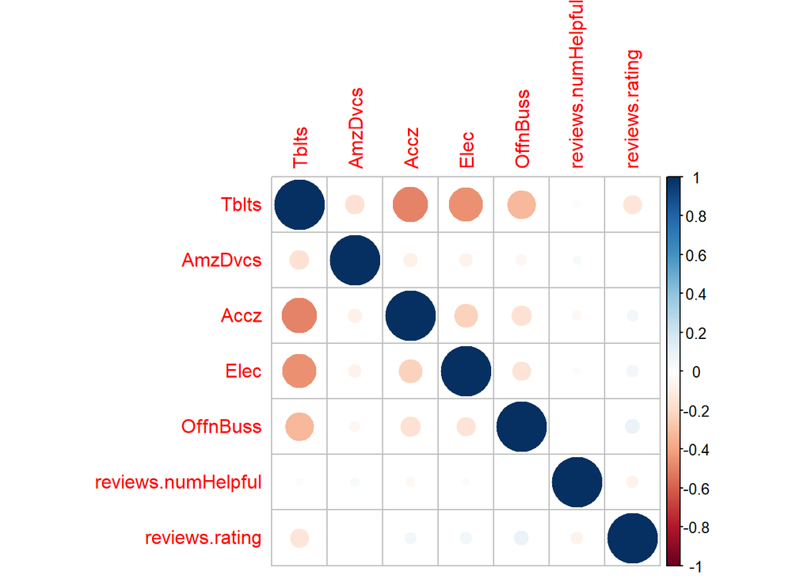

```r
# Calculate correlation matrix
numeric_vars <- df2 %>%
  select(Tblts, AmzDvcs, Accz, Elec, OffnBuss, reviews.numHelpful, reviews.rating)

cor_matrix <- cor(numeric_vars, use = "complete.obs")

# Create the correlation plot
corrplot(cor_matrix, method = "circle")
```

#### Relationship with ratings

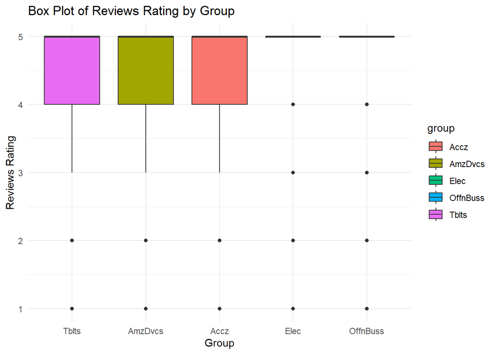

```r
# Convert the dataframe to long format
df2_long <- df2 %>%
  pivot_longer(cols = c("Tblts", "AmzDvcs", "Accz", "Elec", "OffnBuss"), names_to = "group", values_to = "value") %>%
  filter(value == 1)

# Create the box plot
ggplot(df2_long, aes(x = group, y = reviews.rating, fill = group)) +
  geom_boxplot() +
  theme_minimal() +
  labs(x = "Group", y = "Reviews Rating", title = "Box Plot of Reviews Rating by Group") +
  scale_x_discrete(limits = c("Tblts", "AmzDvcs", "Accz", "Elec", "OffnBuss"))
```

#### Scatter plot

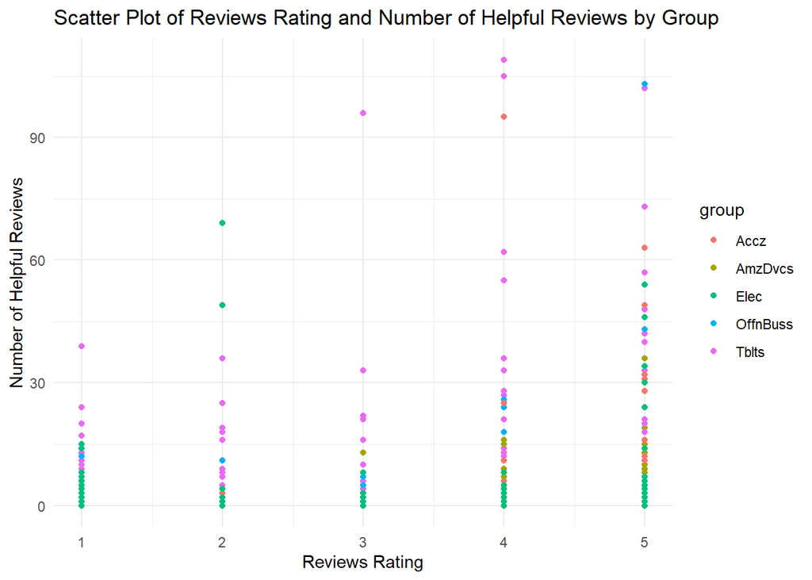

```r
# Create the scatter plot
ggplot(df2_long, aes(x = reviews.rating, y = reviews.numHelpful, color = group)) +
  geom_point() +
  theme_minimal() +
  labs(x = "Reviews Rating", y = "Number of Helpful Reviews", title = "Scatter Plot of Reviews Rating and Number of Helpful Reviews by Group")
```

The scatter plot visualizes the relationship between ‘reviews.rating’ and ‘reviews.numHelpful’ for each of the five groups (Tblts, AmzDvcs, Accz, Elec, and OffnBuss). The plot shows the distribution of data points based on the ratings given by reviewers and the number of helpful reviews for each product in these groups.

```r
cor_matrix[1, 2:6]
```

```
##            AmzDvcs               Accz               Elec           OffnBuss
##         -0.1522882         -0.4980777         -0.4518324         -0.3239152
## reviews.numHelpful
##          0.0216274
```

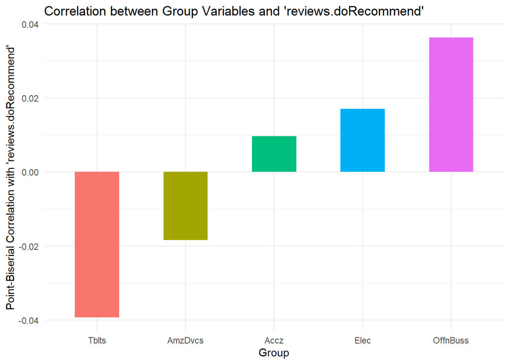

```r
# Select the relevant variables
binary_vars <- df2 %>%
  select(reviews.doRecommend, Tblts, AmzDvcs, Accz, Elec, OffnBuss)

# Calculate the point-biserial correlation matrix
cor_matrix <- cor(binary_vars, use = "complete.obs")


# Create a data frame with the correlation coefficients
cor_data <- data.frame(
  Group = factor(c("Tblts", "AmzDvcs", "Accz", "Elec", "OffnBuss"), levels = c("Tblts", "AmzDvcs", "Accz", "Elec", "OffnBuss")),
  Correlation = c(-0.039260483, -0.018402636, 0.009624345, 0.017048400, 0.036328560)
)

# Create the bar plot
ggplot(cor_data, aes(x = Group, y = Correlation, fill = Group)) +
  geom_bar(stat = "identity", width = 0.5) +
  theme_minimal() +
  ylab("Point-Biserial Correlation with 'reviews.doRecommend'") +
  ggtitle("Correlation between Group Variables and 'reviews.doRecommend'") +
  theme(legend.position = "none")
```

The bar plot displays the point-biserial correlation coefficients between each of the five group variables (Tblts, AmzDvcs, Accz, Elec, and OffnBuss) and the binary variable ‘reviews.doRecommend’. The point-biserial correlation is used to measure the strength and direction of the association between a continuous and a binary variable.

From the plot, we can observe the following:

1. Tblts: This group has a weak negative correlation (-0.039) with ‘reviews.doRecommend’, which indicates that products in this group have a slight tendency to be less recommended by reviewers.
2. AmzDvcs: This group also shows a weak negative correlation (-0.018) with ‘reviews.doRecommend’, implying that products in this group are also slightly less likely to be recommended.
3. Accz: This group has a weak positive correlation (0.010) with ‘reviews.doRecommend’, suggesting that products in this group are slightly more likely to be recommended by reviewers.
4. Elec: This group displays a weak positive correlation (0.017) with ‘reviews.doRecommend’, indicating that products in this group tend to be more recommended by reviewers.
5. OffnBuss: This group has a higher positive correlation (0.036) with ‘reviews.doRecommend’ than the other groups, implying that products in this group are more likely to be recommended by reviewers compared to the other groups.

Overall, the correlations between the group variables and ‘reviews.doRecommend’ are all weak, suggesting that the relationship between the group membership and the likelihood of a product being recommended is not strong

### Finding Groups and Products reputation

#### Counting no. of reviews for each group

```r
# Filter rows with non-empty 'reviews.text'
df2_filtered <- df2 %>% filter(reviews.text != "")

# Calculate the number of reviews for each group
num_reviews_text <- data.frame(
  Group = c("Tblts", "AmzDvcs", "Accz", "Elec", "OffnBuss"),
  NumReviews2 = c(sum(df2_filtered$Tblts), sum(df2_filtered$AmzDvcs), sum(df2_filtered$Accz), sum(df2_filtered$Elec), sum(df2_filtered$OffnBuss))
)

# Display the number of reviews for each group
num_reviews_text
```

```
##      Group NumReviews2
## 1    Tblts       17204
## 2  AmzDvcs         757
## 3     Accz        6662
## 4     Elec        5679
## 5 OffnBuss        3176
```

#### Finding no. of times each group was ‘recommended’ and ‘not_recommended’ by the users.

```r
# Calculate the number of times each group was recommended and not recommended
recommend_count <- df2 %>%
  pivot_longer(cols = c("Tblts", "AmzDvcs", "Accz", "Elec", "OffnBuss"), names_to = "Group", values_to = "value") %>%
  filter(value == 1) %>%
  group_by(Group, reviews.doRecommend) %>%
  summarise(Count = n()) %>%
  pivot_wider(names_from = reviews.doRecommend, values_from = Count, names_prefix = "Recommend_") %>%
  replace_na(list(Recommend_0 = 0, Recommend_1 = 0))
# Display the results
recommend_count
```

```
## # A tibble: 5 × 3
## # Groups:   Group [5]
##   Group    Recommend_FALSE Recommend_TRUE
##   <chr>              <int>          <int>
## 1 Accz                 245           6417
## 2 AmzDvcs               49            708
## 3 Elec                 188           5491
## 4 OffnBuss              58           3118
## 5 Tblts                831          16373
```

#### Stacked bar-plot to show proportion of ‘recommended’ and ‘not_recommended’ of each group.

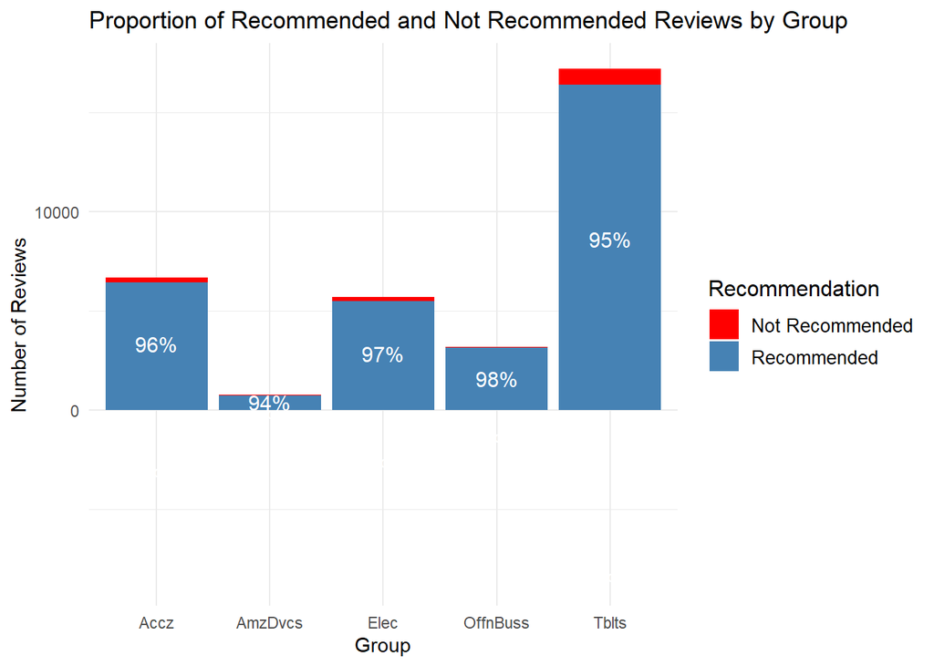

```r
# Add a new column for the count of not recommended reviews
recommend_count$Recommend_FALSE <- recommend_count$Recommend_FALSE

# Calculate the percentage of recommended and not recommended reviews for each group
recommend_count$Recommended_Percentage <- recommend_count$Recommend_TRUE /
                                          (recommend_count$Recommend_TRUE + recommend_count$Recommend_FALSE)
recommend_count$Not_Recommended_Percentage <- recommend_count$Recommend_FALSE /
                                              (recommend_count$Recommend_TRUE + recommend_count$Recommend_FALSE)

# Create the stacked bar plot with percentage labels
ggplot(recommend_count, aes(x = Group, y = Recommend_TRUE + Recommend_FALSE)) +
  geom_bar(aes(fill = "Not Recommended"), stat = "identity") +
  geom_bar(aes(y = Recommend_TRUE, fill = "Recommended"), stat = "identity") +
  geom_text(aes(label = paste0(round(Recommended_Percentage*100), "%")),
            position = position_stack(vjust = 0.5), size = 4, color = "white") +
  geom_text(aes(y = Recommend_TRUE + Recommend_FALSE,
                label = paste0(round(Not_Recommended_Percentage*100), "%")),
            position = position_stack(vjust = -0.5), size = 4, color = "white") +
  scale_fill_manual(values = c("Recommended" = "steelblue", "Not Recommended" = "red")) +
  theme_minimal() +
  labs(x = "Group", y = "Number of Reviews", fill = "Recommendation",
       title = "Proportion of Recommended and Not Recommended Reviews by Group") +
  theme(legend.title = element_text(size = 12), legend.text = element_text(size = 10))
```

#### For each group most of reviews are good and people are recommending each group.

#### Finding out top_10 products that are ‘not_recommended’ by users.

```r
# Calculate the number of reviews and not recommended count for each product
product_reviews <- df2 %>%
  group_by(id, name) %>%
  summarise(Total_Reviews = n(),
            Not_Recommended_Count = sum(!reviews.doRecommend, na.rm = TRUE))
```

[output not shown]

```r
# Calculate the percentage of not recommended reviews
product_reviews <- product_reviews %>%
  mutate(Not_Recommended_Percentage = (Not_Recommended_Count / Total_Reviews) * 100)

# Sort the products by the highest percentage of not recommended reviews and display the top 10
top_10_not_recommended <- product_reviews %>%
  arrange(desc(Not_Recommended_Percentage)) %>%
  head(10)

top_10_not_recommended
```

```
## # A tibble: 10 × 5
## # Groups:   id [7]
##    id           name  Total_Reviews Not_Recommended_Count Not_Recommended_Perc…¹
##    <chr>        <chr>         <int>                 <int>                  <dbl>
##  1 AVphgVaX1cn… "Ama…             1                     1                 100
##  2 AVpfl8cLLJe… "New…             6                     2                  33.3
##  3 AVphgVaX1cn… "Kin…             6                     1                  16.7
##  4 AVqkIj9snnc… "Ama…            12                     2                  16.7
##  5 AVqVGZN9QMl… "Bra…             6                     1                  16.7
##  6 AVpfl8cLLJe… "Ama…             7                     1                  14.3
##  7 AVphgVaX1cn… "Ama…            25                     2                   8
##  8 AVpfpK8KLJe… ""              633                    44                   6.95
##  9 AV1YnR7wglJ… "Ech…           372                    25                   6.72
## 10 AVqVGZNvQMl… "Fir…           211                    14                   6.64
## # ℹ abbreviated name: ¹Not_Recommended_Percentage
```

#### Top 10 products Tree-Map with highest ‘not_recommended’ percentage.

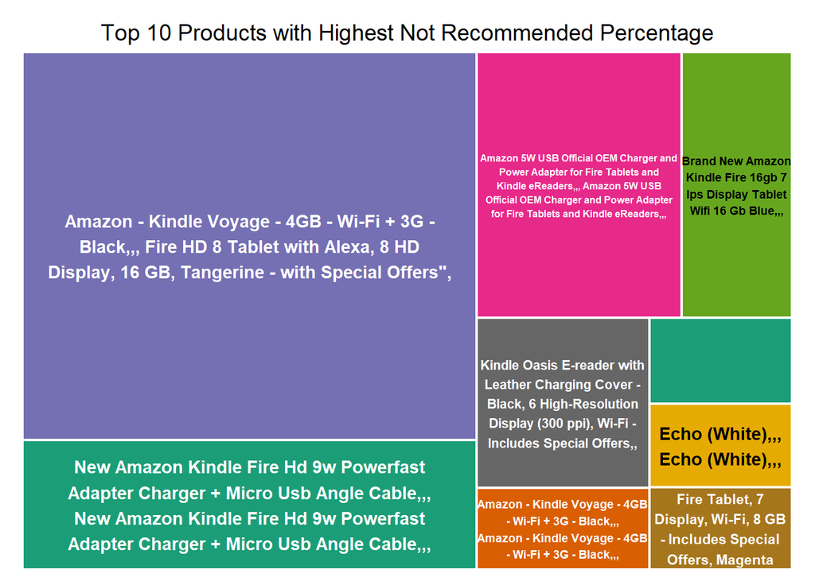

```r
# Create the TreeMap
treemap(top_10_not_recommended,
        index = "name",
        vSize = "Not_Recommended_Percentage",
        title = "Top 10 Products with Highest Not Recommended Percentage",
        fontsize.title = 14,
        palette = "Dark2",
        border.col = "white",
        border.lwds = 2,
        drop.unused.levels = TRUE)
```

### Product Group Summary: Reviews, Recommendations, and Average Ratings (Pivot table)

```r
# Calculate the required summary statistics for each group
pivot_data <- df2 %>%
  group_by(Tblts, AmzDvcs, Accz, Elec, OffnBuss) %>%
  summarise(
    Total_Reviews = n(),
    Recommended_Count = sum(reviews.doRecommend == TRUE),
    Average_Rating = mean(reviews.rating, na.rm = TRUE)
  ) %>%
  mutate(
    Group = case_when(
      Tblts == 1 ~ "Tblts",
      AmzDvcs == 1 ~ "AmzDvcs",
      Accz == 1 ~ "Accz",
      Elec == 1 ~ "Elec",
      OffnBuss == 1 ~ "OffnBuss"
    ),
    Percent_Recommended = (Recommended_Count / Total_Reviews) * 100,
    Not_Recommended_Percentage = 100 - Percent_Recommended
  ) %>%
  select(Group, Percent_Recommended, Not_Recommended_Percentage, Average_Rating, Total_Reviews)
# Print the pivot table
pivot_data %>%
  kable("html", caption = "Your Table Title") %>%
  kable_styling(bootstrap_options = c("striped", "hover", "condensed", "responsive"), full_width = F)
```

| Tblts | AmzDvcs | Accz | Elec | Group | Percent_Recommended | Not_Recommended_Percentage | Average_Rating | Total_Reviews |
| --- | --- | --- | --- | --- | --- | --- | --- | --- |
| 0 | 0 | 0 | 0 | NA | 97.78157 | 2.218430 | 4.730375 | 586 |
| 0 | 0 | 0 | 0 | OffnBuss | 98.17380 | 1.826197 | 4.772355 | 3176 |
| 0 | 0 | 0 | 1 | Elec | 96.68956 | 3.310442 | 4.682338 | 5679 |
| 0 | 0 | 1 | 0 | Accz | 96.32243 | 3.677574 | 4.670519 | 6662 |
| 0 | 1 | 0 | 0 | AmzDvcs | 93.52708 | 6.472919 | 4.560106 | 757 |
| 1 | 0 | 0 | 0 | Tblts | 95.16973 | 4.830272 | 4.490526 | 17204 |

### Cleaning and preprocessing the Text-data in var ‘reviews.text’

```r
# 1. Convert text to lowercase
df2$reviews.text <- tolower(df2$reviews.text)

# 2. Remove special characters and numbers
df2$reviews.text <- gsub("[^[:alpha:][:space:]]", "", df2$reviews.text)

# 3. Remove stopwords
stopwords_list <- stopwords("en")
df2$reviews.text <- removeWords(df2$reviews.text, stopwords_list)

# 4. Perform stemming or lemmatization
df2$reviews.text <- wordStem(df2$reviews.text, language = "en")
```

### creating TF-IDF matrix ‘tfidf_df’ for var ‘reviews.text’ (Term Frequency- Inverse Document Frequency)

```r
# 5. Create a document-term matrix or a term frequency-inverse document frequency (TF-IDF) matrix
tokens <- tokens(df2$reviews.text, remove_punct = TRUE)
dtm <- dfm(tokens)
tfidf_matrix <- dfm_tfidf(dtm)
print(tfidf_matrix)
```

```
## Document-feature matrix of: 34,064 documents, 17,601 features (99.92% sparse) and 0 docvars.
##        features
## docs     product      far disappointed children      love       use     like
##   text1 1.019078 1.555487     2.296767 1.929151 0.7655111 0.7555945 1.022959
##   text2 0        0            0        0        0         0         0
##   text3 0        0            0        0        0         0.7555945 0
##   text4 0        0            0        0        1.5310223 0         1.022959
##   text5 0        0            0        0        0         0         0
##   text6 0        0            0        0        0         0         0
##        features
## docs     ability  monitor  control
##   text1 2.045157 2.930236 1.689063
##   text2 0        0        0
##   text3 0        0        0
##   text4 0        0        0
##   text5 0        0        0
##   text6 0        0        0
## [ reached max_ndoc ... 34,058 more documents, reached max_nfeat ... 17,591 more features ]
```

#### The matrix has 34,064 documents (rows) and 17,601 features (columns). The sparsity of the matrix is 99.92%, meaning that most of the elements in the matrix are zeros.

#### In the TF-IDF matrix, each row represents a document (in this case, a review), and each column represents a unique word (feature) found in the dataset. The values in the matrix represent the importance of each word in a specific document. A higher value for a word in a particular document means that the word is more significant in that document. Conversely, a value of zero means that the word does not appear in the document or has low importance.

#### The matrix helps in understanding the content of the reviews and can be used for various text analysis tasks, such as sentiment analysis, topic modeling, or document classification.

### Cleaning, pre-processing the Text-data and creating TF-IDF matrix ‘title_tfidf_matrix’ for var ‘reviews.title’

```r
# 1. Convert text to lowercase
df2$reviews.title <- tolower(df2$reviews.title)

# 2. Remove special characters and numbers
df2$reviews.title <- gsub("[^[:alpha:][:space:]]", "", df2$reviews.title)

# 3. Remove stopwords
stopwords_list <- stopwords("en")
df2$reviews.title <- removeWords(df2$reviews.title, stopwords_list)

# 4. Perform stemming or lemmatization
df2$reviews.title <- wordStem(df2$reviews.title, language = "en")

# 5. Create a document-term matrix or a term frequency-inverse document frequency (TF-IDF) matrix
title_tokens <- tokens(df2$reviews.title, remove_punct = TRUE)
title_dtm <- dfm(title_tokens)
title_tfidf_matrix <- dfm_tfidf(title_dtm)
print(title_tfidf_matrix)
```

```
## Document-feature matrix of: 34,064 documents, 3,909 features (99.94% sparse) and 0 docvars.
##        features
## docs       kindl     fast beginner    tablet     year      old      son
##   text1 1.773384 0        0        0         0        0        0
##   text2 0        2.339171 0        0         0        0        0
##   text3 0        0        2.634669 0.7709693 2.189873 2.029869 2.344775
##   text4 0        0        0        0         0        0        0
##   text5 0        0        0        0.7709693 0        0        0
##   text6 0        0        0        0         0        0        0
##        features
## docs        good fantastic      kid
##   text1 0         0        0
##   text2 0         0        0
##   text3 0         0        0
##   text4 1.046432  0        0
##   text5 0         2.568508 1.439926
##   text6 0         0        0
## [ reached max_ndoc ... 34,058 more documents, reached max_nfeat ... 3,899 more features ]
```

## Using dataset df2

```r
suppressMessages(library(sentimentr))
```

```r
names(df2)
```

```
##  [1] "id"                  "name"                "asins"
##  [4] "brand"               "categories"          "keys"
##  [7] "manufacturer"        "reviews.date"        "reviews.dateAdded"
## [10] "reviews.dateSeen"    "reviews.doRecommend" "reviews.numHelpful"
## [13] "reviews.rating"      "reviews.sourceURLs"  "reviews.text"
## [16] "reviews.title"       "reviews.username"    "rating_color"
## [19] "Tblts"               "AmzDvcs"             "Accz"
## [22] "Elec"                "OffnBuss"
```

```r
dim(df2)
```

```
## [1] 34064    23
```

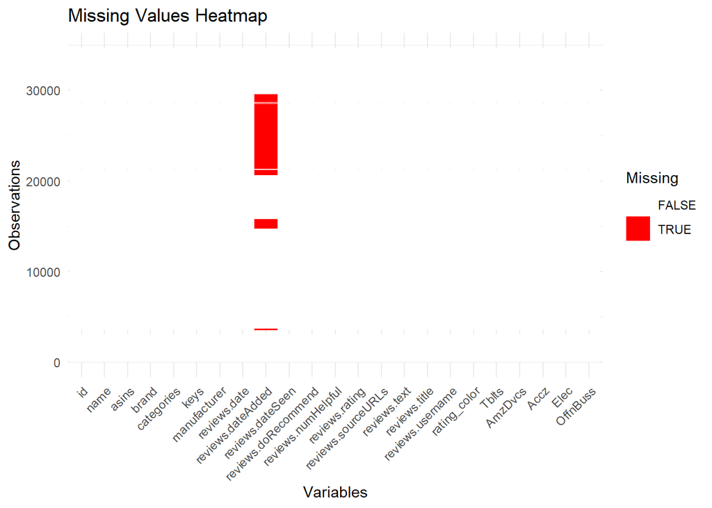

```r
# Create a binary matrix indicating missing values
missing_values <- is.na(df2)

# Convert the binary matrix to a long format data frame
missing_values_long <- melt(missing_values, id.vars = row.names(missing_values))

# Create a heatmap using ggplot2
ggplot(data = missing_values_long, aes(x = Var2, y = Var1, fill = value)) +
  geom_tile() +
  theme_minimal() +
  theme(axis.text.x = element_text(angle = 45, hjust = 1)) +
  labs(x = "Variables", y = "Observations", title = "Missing Values Heatmap") +
  scale_fill_manual(values = c("white", "red"), name = "Missing")
```

```r
sum(is.na(df2))
```

```
## [1] 10031
```

```r
# Calculate sentiment scores
sentiment_scores <- sentiment(df2$reviews.text)
# Add sentiment scores to the dataset
df2$snt_scr_text <- sentiment_scores$sentiment
```

```r
head(df2$snt_scr_text)
```

```
## [1] 0.3744226 0.9827076 0.8221922 1.3969270 0.8682080 0.2867697
```

```r
# Calculate sentiment scores for "reviews.title"
sentiment_scores_title <- sentiment(df2$reviews.title)
# Add sentiment scores to the dataset
df2$snt_scr_title <- sentiment_scores_title$sentiment
```

```r
head(df2$snt_scr_title)
```

```
## [1] 0.0000000 1.0000000 0.0000000 0.7500000 0.4330127 0.2828427
```

```r
min(df2$snt_scr_text)
```

```
## [1] -1.285982
```

```r
max(df2$snt_scr_text)
```

```
## [1] 2.894
```

```r
names(df2)
```

```
##  [1] "id"                  "name"                "asins"
##  [4] "brand"               "categories"          "keys"
##  [7] "manufacturer"        "reviews.date"        "reviews.dateAdded"
## [10] "reviews.dateSeen"    "reviews.doRecommend" "reviews.numHelpful"
## [13] "reviews.rating"      "reviews.sourceURLs"  "reviews.text"
## [16] "reviews.title"       "reviews.username"    "rating_color"
## [19] "Tblts"               "AmzDvcs"             "Accz"
## [22] "Elec"                "OffnBuss"            "snt_scr_text"
## [25] "snt_scr_title"
```

### Distribution of Sentiment Scores for Reviews.Text & Reviews.Title

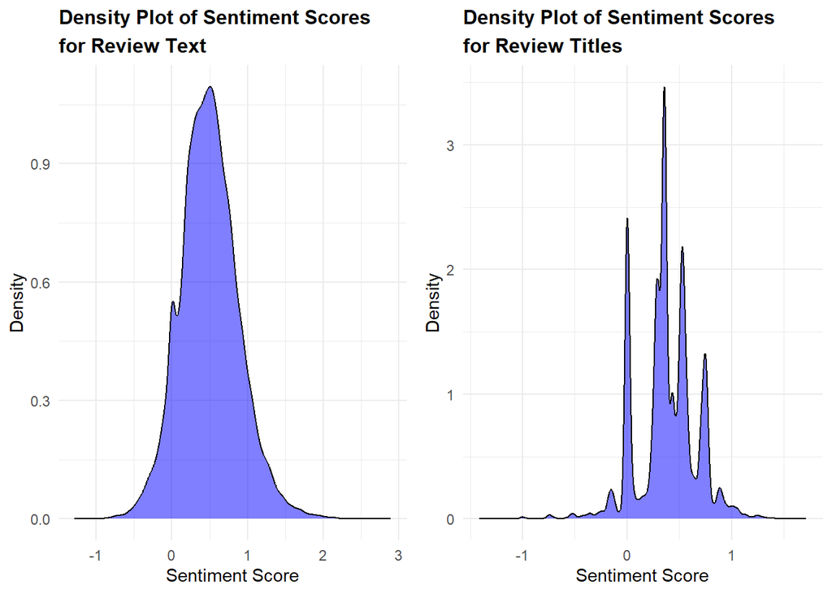

```r
# Create a density plot for snt_scr_text
text_plot <- ggplot(df2, aes(x = snt_scr_text)) +
  geom_density(fill = "blue", alpha = 0.5) +
  theme_minimal() +
  labs(title = "Density Plot of Sentiment Scores\nfor Review Text",
       x = "Sentiment Score",
       y = "Density") +
  theme(plot.title = element_text(size = 12, lineheight = 1.2, face = "bold"))

# Create a density plot for snt_scr_title
title_plot <- ggplot(df2, aes(x = snt_scr_title)) +
  geom_density(fill = "blue", alpha = 0.5) +
  theme_minimal() +
  labs(title = "Density Plot of Sentiment Scores\nfor Review Titles",
       x = "Sentiment Score",
       y = "Density") +
  theme(plot.title = element_text(size = 12, lineheight = 1.2, face = "bold"))

# Display the plots side by side
grid.arrange(text_plot, title_plot, ncol = 2)
```

### Creating new dataset ‘df3’ with only important variables

### 1. reviews.doRecommend,

### 2. reviews.rating,

### 3. snt_scr_text,

### 4. snt_scr_title

### 5. Tblts, 6. AmzDvcs,7. Accz, 8. Elec, 9. OffnBuss,

### and dropping of the others variables that are not adding any value after thorough testing and exploration.

```r
# Create a new dataset with selected variables
df3 <- df2[, c("reviews.doRecommend", "reviews.rating", "Tblts", "AmzDvcs", "Accz", "Elec", "OffnBuss", "snt_scr_text", "snt_scr_title")]

# Display the first few rows of the new dataset
head(df3)
```

```
##   reviews.doRecommend reviews.rating Tblts AmzDvcs Accz Elec OffnBuss
## 1                TRUE              5     1       0    0    0        0
## 2                TRUE              5     1       0    0    0        0
## 3                TRUE              5     1       0    0    0        0
## 4                TRUE              4     1       0    0    0        0
## 5                TRUE              5     1       0    0    0        0
## 6                TRUE              5     1       0    0    0        0
##   snt_scr_text snt_scr_title
## 1    0.3744226     0.0000000
## 2    0.9827076     1.0000000
## 3    0.8221922     0.0000000
## 4    1.3969270     0.7500000
## 5    0.8682080     0.4330127
## 6    0.2867697     0.2828427
```

```r
str(df3)
```

```
## 'data.frame':    34064 obs. of  9 variables:
##  $ reviews.doRecommend: logi  TRUE TRUE TRUE TRUE TRUE TRUE ...
##  $ reviews.rating     : num  5 5 5 4 5 5 4 5 5 5 ...
##  $ Tblts              : num  1 1 1 1 1 1 1 1 1 1 ...
##  $ AmzDvcs            : num  0 0 0 0 0 0 0 0 0 0 ...
##  $ Accz               : num  0 0 0 0 0 0 0 0 0 0 ...
##  $ Elec               : num  0 0 0 0 0 0 0 0 0 0 ...
##  $ OffnBuss           : num  0 0 0 0 0 0 0 0 0 0 ...
##  $ snt_scr_text       : num  0.374 0.983 0.822 1.397 0.868 ...
##  $ snt_scr_title      : num  0 1 0 0.75 0.433 ...
```

```r
library(hexbin)
```

#### 1. Assessing relationship b/w ‘snt_scr_text’ and ‘reviews.rating’.

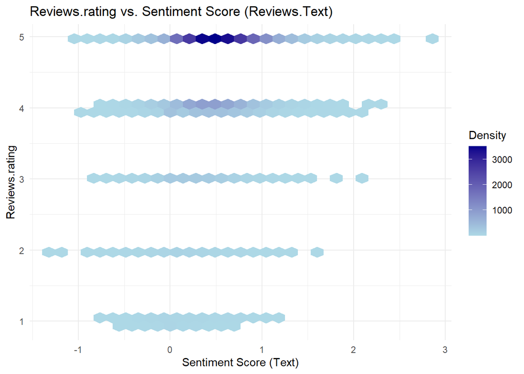

```r
ggplot(df3, aes(x = snt_scr_text, y = reviews.rating)) +
  geom_hex(bins = 30) +
  labs(title = "Reviews.rating vs. Sentiment Score (Reviews.Text)",
       x = "Sentiment Score (Text)",
       y = "Reviews.rating") +
  theme_minimal() +
  scale_fill_gradient(low = "lightblue", high = "darkblue", name = "Density")
```

#### 2. Assessing relationship b/w ‘snt_scr_title’ and ‘reviews.rating’

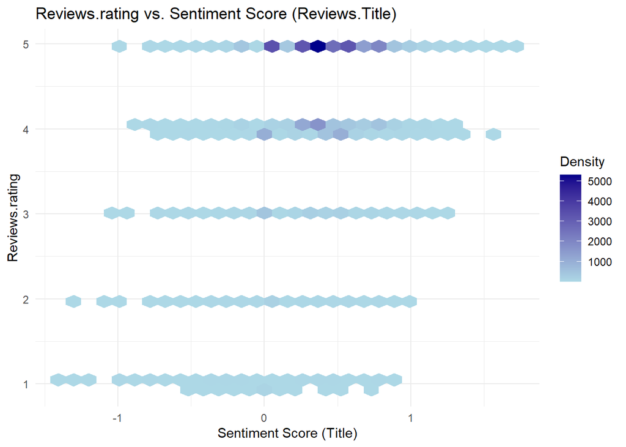

```r
ggplot(df3, aes(x = snt_scr_title, y = reviews.rating)) +
  geom_hex(bins = 30) +
  labs(title = "Reviews.rating vs. Sentiment Score (Reviews.Title)",
       x = "Sentiment Score (Title)",
       y = "Reviews.rating") +
  theme_minimal() +
  scale_fill_gradient(low = "lightblue", high = "darkblue", name = "Density")
```

#### 3. Assessing relationship b/w ‘snt_scr_text’ and ‘reviews.doRecommend’

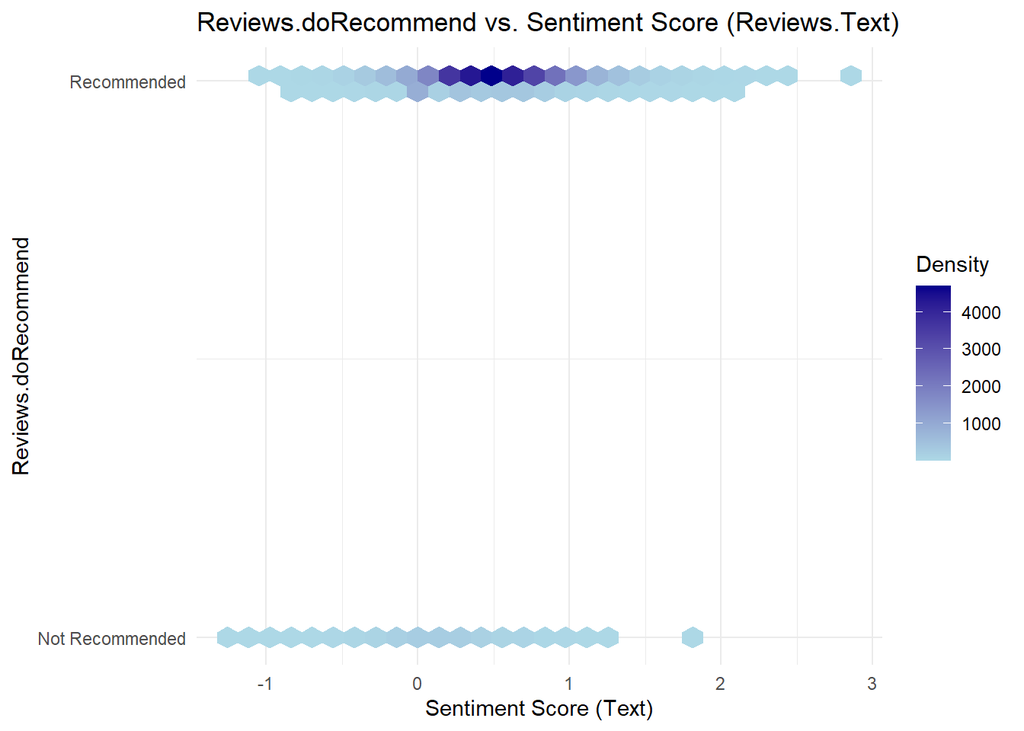

```r
ggplot(df3, aes(x = snt_scr_text, y = as.numeric(reviews.doRecommend))) +
  geom_hex(bins = 30) +
  labs(title = "Reviews.doRecommend vs. Sentiment Score (Reviews.Text)",
       x = "Sentiment Score (Text)",
       y = "Reviews.doRecommend") +
  theme_minimal() +
  scale_fill_gradient(low = "lightblue", high = "darkblue", name = "Density") +
  scale_y_continuous(breaks = c(0, 1), labels = c("Not Recommended", "Recommended"))
```

#### 4. Assessing relationship b/w ‘snt_scr_title’ and ‘reviews.doRecommend’

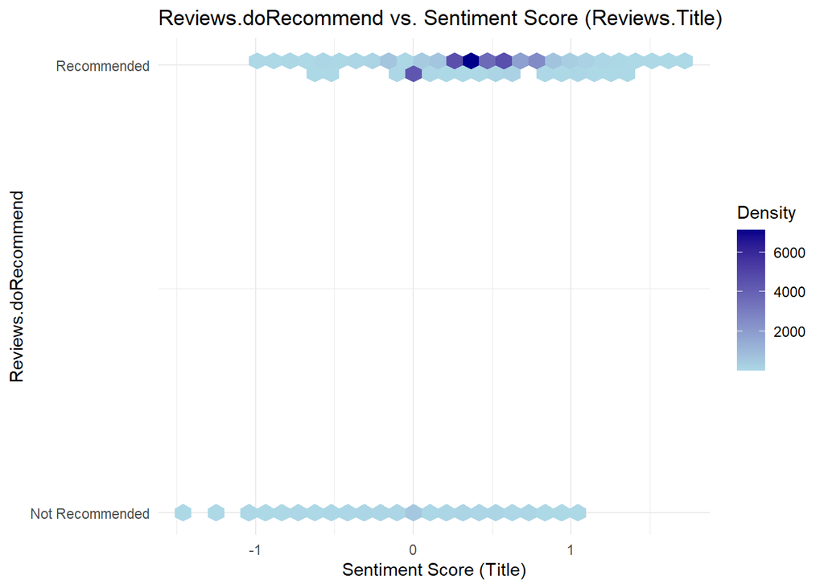

```r
ggplot(df3, aes(x = snt_scr_title, y = as.numeric(reviews.doRecommend))) +
  geom_hex(bins = 30) +
  labs(title = "Reviews.doRecommend vs. Sentiment Score (Reviews.Title)",
       x = "Sentiment Score (Title)",
       y = "Reviews.doRecommend") +
  theme_minimal() +
  scale_fill_gradient(low = "lightblue", high = "darkblue", name = "Density") +
  scale_y_continuous(breaks = c(0, 1), labels = c("Not Recommended", "Recommended"))
```

```r
# Create new variables to check if sentiment scores are positive
df3$snt_text_positive <- df3$snt_scr_text > 0
df3$snt_title_positive <- df3$snt_scr_title > 0

# Calculate the proportion of 5-star ratings when sentiment scores are positive
prop_rating5_snt_text_positive <- mean(df3[df3$snt_text_positive,]$reviews.rating == 5)
prop_rating5_snt_title_positive <- mean(df3[df3$snt_title_positive,]$reviews.rating == 5)

# Calculate the proportion of 5-star ratings when sentiment scores are negative or zero
prop_rating5_snt_text_negative <- mean(df3[!df3$snt_text_positive,]$reviews.rating == 5)
prop_rating5_snt_title_negative <- mean(df3[!df3$snt_title_positive,]$reviews.rating == 5)

# Print the proportions
cat("Proportion of 5-star ratings when snt_scr_text is positive:", prop_rating5_snt_text_positive, "\n")
```

```
## Proportion of 5-star ratings when snt_scr_text is positive: 0.7045671
```

```r
cat("Proportion of 5-star ratings when snt_scr_title is positive:", prop_rating5_snt_title_positive, "\n")
```

```
## Proportion of 5-star ratings when snt_scr_title is positive: 0.7035932
```

```r
cat("Proportion of 5-star ratings when snt_scr_text is negative or zero:", prop_rating5_snt_text_negative, "\n")
```

```
## Proportion of 5-star ratings when snt_scr_text is negative or zero: 0.5326972
```

```r
cat("Proportion of 5-star ratings when snt_scr_title is negative or zero:", prop_rating5_snt_title_negative, "\n")
```

```
## Proportion of 5-star ratings when snt_scr_title is negative or zero: 0.6106833
```

#### Assessing relationship b/w Sentiment scores with ratings given by customers.

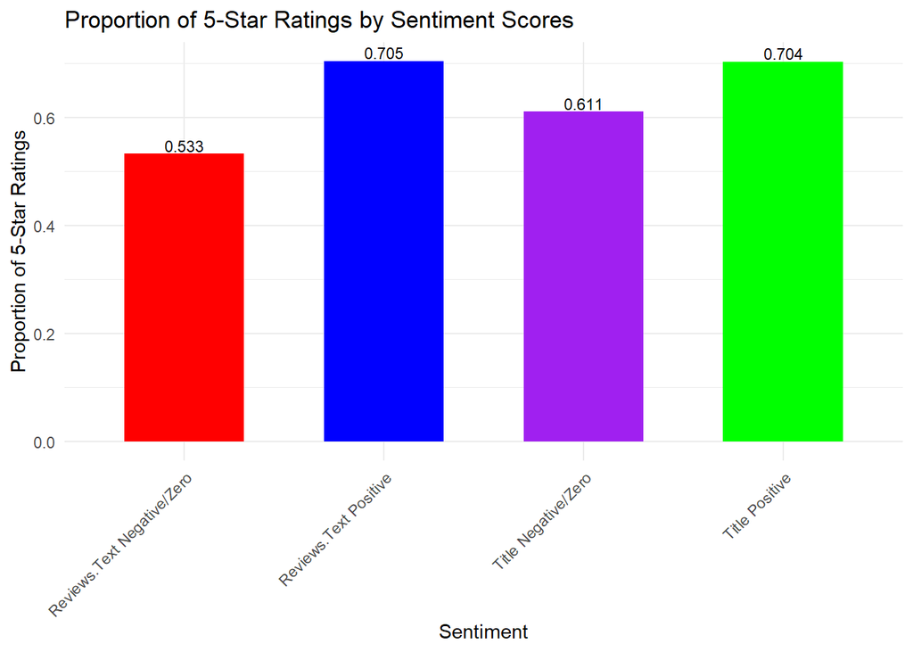

```r
# Create a summary dataframe
summary_df <- data.frame(
  Sentiment = c("Reviews.Text Positive", "Reviews.Text Negative/Zero", "Title Positive", "Title Negative/Zero"),
  Proportion = c(prop_rating5_snt_text_positive, prop_rating5_snt_text_negative, prop_rating5_snt_title_positive, prop_rating5_snt_title_negative)
)

# Create a bar plot
ggplot(summary_df, aes(x = Sentiment, y = Proportion, fill = Sentiment)) +
  geom_bar(stat = "identity", width = 0.6) +
  scale_fill_manual(values = c("Reviews.Text Positive" = "blue",
                               "Reviews.Text Negative/Zero" = "red",
                               "Title Positive" = "green",
                               "Title Negative/Zero" = "purple")) +
  labs(title = "Proportion of 5-Star Ratings by Sentiment Scores",
       x = "Sentiment",
       y = "Proportion of 5-Star Ratings") +
  theme_minimal() +
  theme(axis.text.x = element_text(angle = 45, hjust = 1),
        legend.position = "none") +
  geom_text(aes(label = round(Proportion, 3)), vjust = -0.2, size = 3)
```

The output shows the proportion of 5-star ratings when sentiment scores for the review text and title are positive or negative/zero. The results can be interpreted as follows:

- When the sentiment score for the review text (`snt_scr_text`) is positive, approximately 70.46% of the ratings are 5-star ratings.
- When the sentiment score for the review title (`snt_scr_title`) is positive, approximately 70.36% of the ratings are 5-star ratings.
- When the sentiment score for the review text (`snt_scr_text`) is negative or zero, approximately 53.27% of the ratings are 5-star ratings.
- When the sentiment score for the review title (`snt_scr_title`) is negative or zero, approximately 61.07% of the ratings are 5-star ratings.

These results indicate that there is a positive relationship between sentiment scores and the likelihood of a 5-star rating. When the sentiment scores for the review text and title are positive, a higher proportion of the ratings are 5-star compared to when the sentiment scores are negative or zero. This suggests that customers tend to give higher ratings when their reviews express positive sentiments.

#### Assessing relationship b/w Sentiment scores with product recommendation status.

```r
# Calculate proportions for recommendations when snt_scr_text is positive, negative, or zero
positive_text <- df3[df3$snt_scr_text > 0, ]
negative_or_zero_text <- df3[df3$snt_scr_text <= 0, ]

prop_recommend_positive_text <- sum(positive_text$reviews.doRecommend) / nrow(positive_text)
prop_recommend_negative_zero_text <- sum(negative_or_zero_text$reviews.doRecommend) / nrow(negative_or_zero_text)

# Calculate proportions for recommendations when snt_scr_title is positive, negative, or zero
positive_title <- df3[df3$snt_scr_title > 0, ]
negative_or_zero_title <- df3[df3$snt_scr_title <= 0, ]

prop_recommend_positive_title <- sum(positive_title$reviews.doRecommend) / nrow(positive_title)
prop_recommend_negative_zero_title <- sum(negative_or_zero_title$reviews.doRecommend) / nrow(negative_or_zero_title)

# Print the results
cat("Proportion of recommendations when snt_scr_text is positive:", prop_recommend_positive_text, "\n")
```

```
## Proportion of recommendations when snt_scr_text is positive: 0.9709846
```

```r
cat("Proportion of recommendations when snt_scr_text is negative or zero:", prop_recommend_negative_zero_text, "\n")
```

```
## Proportion of recommendations when snt_scr_text is negative or zero: 0.8599495
```

```r
cat("Proportion of recommendations when snt_scr_title is positive:", prop_recommend_positive_title, "\n")
```

```
## Proportion of recommendations when snt_scr_title is positive: 0.9796622
```

```r
cat("Proportion of recommendations when snt_scr_title is negative or zero:", prop_recommend_negative_zero_title, "\n")
```

```
## Proportion of recommendations when snt_scr_title is negative or zero: 0.8687841
```

#### Assessing relationship b/w Sentiment scores with product recommendation status.

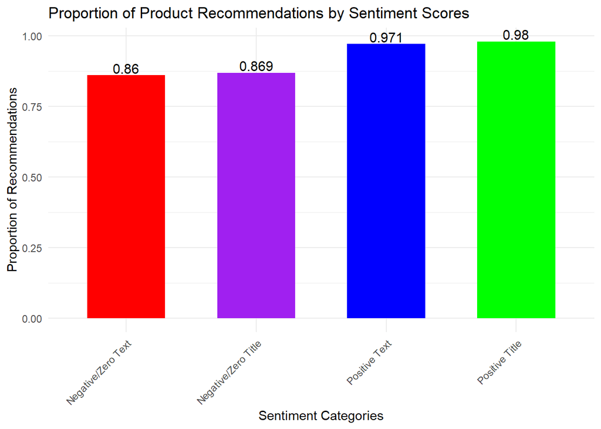

```r
# Create a data frame for visualization
recommendation_proportions <- data.frame(
  Sentiment = c("Positive Text", "Negative/Zero Text", "Positive Title", "Negative/Zero Title"),
  Proportion = c(prop_recommend_positive_text, prop_recommend_negative_zero_text,
                 prop_recommend_positive_title, prop_recommend_negative_zero_title)
)

# Create a bar plot
ggplot(recommendation_proportions, aes(x = Sentiment, y = Proportion, fill = Sentiment)) +
  geom_bar(stat = "identity", width = 0.6) +
  scale_fill_manual(values = c("Positive Text" = "blue",
                               "Negative/Zero Text" = "red",
                               "Positive Title" = "green",
                               "Negative/Zero Title" = "purple")) +
  labs(title = "Proportion of Product Recommendations by Sentiment Scores",
       x = "Sentiment Categories",
       y = "Proportion of Recommendations") +
  theme_minimal() +
  theme(axis.text.x = element_text(angle = 45, hjust = 1),
        legend.position = "none") +
  geom_text(aes(label = round(Proportion, 3)), vjust = -0.2, size = 4)
```

This output provides information on the proportion of recommendations in four different scenarios related to sentiment scores (snt_scr) for text and title. Sentiment scores are typically used to determine the positivity or negativity of a given text or title.

In summary, the system is more likely to make a recommendation when the sentiment scores for both text and title are positive, compared to when the sentiment scores are negative or neutral.

## Business question 1: Predict whether customer is gonna recommend the product or not?

#### creating a copy of dataset df3 as ‘df3_b1’ for business question 1.

```r
# Create a copy of df3 named df3_b1
df3_b1 <- df3
```

#### Looking at original distribution of ‘reviews.doRecommend’

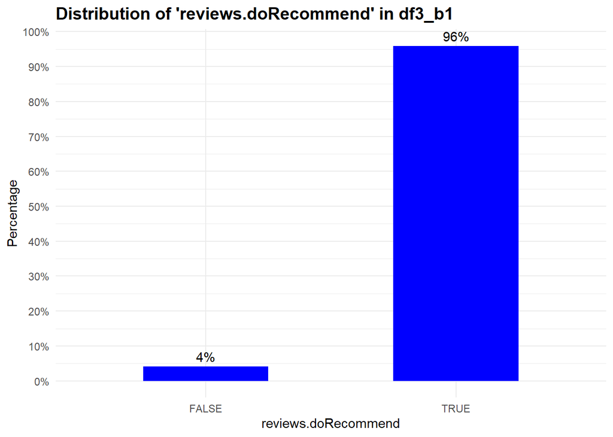

```r
# Create a bar plot for the distribution of 'reviews.doRecommend'
p <- ggplot(df3_b1, aes(x = reviews.doRecommend)) +
  geom_bar(aes(y = ..count.. / sum(..count..)), fill = "blue", width = 0.5) +
  scale_y_continuous(labels = scales::percent, breaks = seq(0, 1, 0.1)) +
  theme_minimal() +
  labs(title = "Distribution of 'reviews.doRecommend' in df3_b1",
       x = "reviews.doRecommend",
       y = "Percentage") +
  theme(plot.title = element_text(size = 14, face = "bold"))

# Add percentage labels over the bars
p + geom_text(aes(label = scales::percent(..count.. / sum(..count..)),
                  y = ..count.. / sum(..count..)),
              stat = "count",
              vjust = -0.5)
```

#### Partitioning the dataset ‘df3_b1’ 70-20-10.

```r
# Set the seed for reproducibility
set.seed(42)

# Calculate the number of rows for each partition
n <- nrow(df3_b1)
n_train <- floor(0.7 * n)
n_validation <- floor(0.2 * n)
n_test <- n - n_train - n_validation

# Create a random index for the dataset
idx <- sample(1:n)

# Split the dataset into training (70%), validation (20%), and testing (10%) sets
train_df3_b1 <- df3_b1[idx[1:n_train], ]
validation_df3_b1 <- df3_b1[idx[(n_train + 1):(n_train + n_validation)], ]
test_df3_b1 <- df3_b1[idx[(n_train + n_validation + 1):n], ]

# Display the number of rows for each partition
cat("Training set rows:", nrow(train_df3_b1), "\n")
```

```
## Training set rows: 23844
```

```r
cat("Validation set rows:", nrow(validation_df3_b1), "\n")
```

```
## Validation set rows: 6812
```

```r
cat("Testing set rows:", nrow(test_df3_b1), "\n")
```

```
## Testing set rows: 3408
```

#### looking at no. of True & False

```r
table(train_df3_b1$reviews.doRecommend)
```

```
##
## FALSE  TRUE
##   971 22873
```

### Checking correlation b/w continuous independent variables “snt_scr_text”, “snt_scr_title”, and “reviews.rating”.

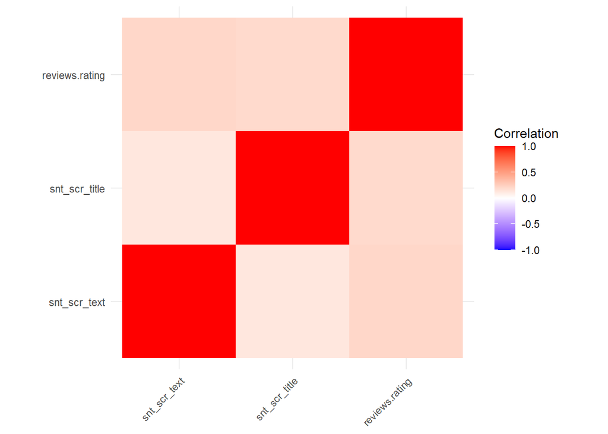

```r
# Calculate correlation matrix for continuous independent variables
corr_matrix <- cor(df3_b1[, c("snt_scr_text", "snt_scr_title", "reviews.rating")])

# Melt the correlation matrix for ggplot2
melted_corr_matrix <- melt(corr_matrix)

# Create the heatmap
ggplot(data = melted_corr_matrix, aes(x = Var1, y = Var2, fill = value)) +
  geom_tile() +
  scale_fill_gradient2(low = "blue", high = "red", mid = "white", midpoint = 0, limit = c(-1,1), name = "Correlation") +
  theme_minimal() +
  theme(axis.text.x = element_text(angle = 45, vjust = 1, hjust = 1),
        axis.title = element_blank()) +
  coord_fixed()
```

#### Balancing the dep var ‘reviews.doRecommend’ 50-50. Method used ‘random oversampling’.

#### Original distribution was 96% Recommended and 4% not recommend. Changed it 50% recommended 50% not recommened.Balanced the training dataset by oversampling the minority class to achieve an equal proportion of “True” and “False” observations.

#### Original train_df3_b1 observations = 23,844

#### After balaning train_df3_b1 observations = 45,466

```r
train_df3_b1$reviews.doRecommend <- as.factor(train_df3_b1$reviews.doRecommend)
```

```r
set.seed(123) # For reproducibility
ovun_train_df3_b1 <- ovun.sample(reviews.doRecommend ~ ., data = train_df3_b1, method = "over", p = 0.5)$data
```

```r
table(ovun_train_df3_b1$reviews.doRecommend)
```

```
##
##  TRUE FALSE
## 22873 22593
```

#### using undersampling method to balance the dataset ‘train_df3_b1’

```r
set.seed(123) # For reproducibility
und_train_df3_b1 <- ovun.sample(reviews.doRecommend ~ ., data = train_df3_b1, method = "under", p = 0.5)$data

table(und_train_df3_b1$reviews.doRecommend)
```

```
##
##  TRUE FALSE
##   968   971
```

```r
str(und_train_df3_b1)
```

```
## 'data.frame':    1939 obs. of  11 variables:
##  $ reviews.doRecommend: Factor w/ 2 levels "TRUE","FALSE": 1 1 1 1 1 1 1 1 1 1 ...
##  $ reviews.rating     : num  5 5 4 5 5 5 5 5 5 5 ...
##  $ Tblts              : num  0 0 0 0 0 0 0 1 0 0 ...
##  $ AmzDvcs            : num  0 0 0 1 0 0 0 0 0 0 ...
##  $ Accz               : num  0 0 0 0 1 1 1 0 0 0 ...
##  $ Elec               : num  0 1 1 0 0 0 0 0 0 1 ...
##  $ OffnBuss           : num  1 0 0 0 0 0 0 0 1 0 ...
##  $ snt_scr_text       : num  0.224 0.342 0.531 0.964 0.237 ...
##  $ snt_scr_title      : num  0.491 0 0.433 0.354 0.53 ...
##  $ snt_text_positive  : logi  TRUE TRUE TRUE TRUE TRUE TRUE ...
##  $ snt_title_positive : logi  TRUE FALSE TRUE TRUE TRUE TRUE ...
```

#### Runing logistic on balanced dataset with undersampling ‘und_train_df3_b1’

```r
logistic_model_b1_under <- glm(reviews.doRecommend ~ reviews.rating + Tblts + AmzDvcs + Accz + Elec + OffnBuss + snt_scr_text + snt_scr_title,
                               data = und_train_df3_b1,
                               family = binomial)

summary(logistic_model_b1_under)
```

```
##
## Call:
## glm(formula = reviews.doRecommend ~ reviews.rating + Tblts +
##     AmzDvcs + Accz + Elec + OffnBuss + snt_scr_text + snt_scr_title,
##     family = binomial, data = und_train_df3_b1)
##
## Deviance Residuals:
##      Min        1Q    Median        3Q       Max
## -3.15357  -0.31453   0.01469   0.28155   2.97813
##
## Coefficients:
##                Estimate Std. Error z value Pr(>|z|)
## (Intercept)     10.1273     0.8308  12.190  < 2e-16 ***
## reviews.rating  -2.4373     0.1175 -20.735  < 2e-16 ***
## Tblts           -0.5955     0.6751  -0.882  0.37770
## AmzDvcs          0.8127     0.8157   0.996  0.31913
## Accz             0.6077     0.6858   0.886  0.37557
## Elec            -0.3700     0.6971  -0.531  0.59552
## OffnBuss        -0.3098     0.7346  -0.422  0.67329
## snt_scr_text    -1.3557     0.2407  -5.632 1.78e-08 ***
## snt_scr_title   -0.8277     0.2870  -2.884  0.00393 **
## ---
## Signif. codes:  0 '***' 0.001 '**' 0.01 '*' 0.05 '.' 0.1 ' ' 1
##
## (Dispersion parameter for binomial family taken to be 1)
##
##     Null deviance: 2688.02  on 1938  degrees of freedom
## Residual deviance:  953.72  on 1930  degrees of freedom
## AIC: 971.72
##
## Number of Fisher Scoring iterations: 6
```

#### Running confusion matrix

```r
# Predict probabilities
val_prob_b1_under <- predict(logistic_model_b1_under, newdata = validation_df3_b1, type = "response")
```

```r
# Convert probabilities to binary predictions (TRUE or FALSE) using a threshold of 0.5
val_predictions_b1_under <- ifelse(val_prob_b1_under > 0.5, "TRUE", "FALSE")
val_predictions_b1_under <- factor(val_predictions_b1_under, levels = levels(validation_df3_b1$reviews.doRecommend))
```

```r
# suppressMessages(library(caret))
# # Create a confusion matrix
# actual_values_b1 <- validation_df3_b1$reviews.doRecommend
# conf_matrix_b1_under <- confusionMatrix(val_predictions_b1_under, actual_values_b1)
# conf_matrix_b1_under
```

#### Imbalanced training data “train_df3_b1”

#### Balanced training data “ovun_train_df3_b1”

```r
head(train_df3_b1)
```

```
##       reviews.doRecommend reviews.rating Tblts AmzDvcs Accz Elec OffnBuss
## 34581                TRUE              5     0       0    0    1        0
## 9256                 TRUE              4     1       0    0    0        0
## 17184                TRUE              5     1       0    0    0        0
## 8130                 TRUE              5     1       0    0    0        0
## 9521                 TRUE              4     1       0    0    0        0
## 34261                TRUE              4     0       0    0    1        0
##       snt_scr_text snt_scr_title snt_text_positive snt_title_positive
## 34581    0.9333333     0.7071068              TRUE               TRUE
## 9256     0.2347871     0.3535534              TRUE               TRUE
## 17184    0.7778175     0.3535534              TRUE               TRUE
## 8130     0.2236068     0.3535534              TRUE               TRUE
## 9521     1.0063534     0.7071068              TRUE               TRUE
## 34261    0.4822615     0.6235383              TRUE               TRUE
```

```r
head(ovun_train_df3_b1)
```

```
##   reviews.doRecommend reviews.rating Tblts AmzDvcs Accz Elec OffnBuss
## 1                TRUE              5     0       0    0    1        0
## 2                TRUE              4     1       0    0    0        0
## 3                TRUE              5     1       0    0    0        0
## 4                TRUE              5     1       0    0    0        0
## 5                TRUE              4     1       0    0    0        0
## 6                TRUE              4     0       0    0    1        0
##   snt_scr_text snt_scr_title snt_text_positive snt_title_positive
## 1    0.9333333     0.7071068              TRUE               TRUE
## 2    0.2347871     0.3535534              TRUE               TRUE
## 3    0.7778175     0.3535534              TRUE               TRUE
## 4    0.2236068     0.3535534              TRUE               TRUE
## 5    1.0063534     0.7071068              TRUE               TRUE
## 6    0.4822615     0.6235383              TRUE               TRUE
```

```r
dim(train_df3_b1)
```

```
## [1] 23844    11
```

```r
dim(ovun_train_df3_b1)
```

```
## [1] 45466    11
```

```r
str(ovun_train_df3_b1)
```

```
## 'data.frame':    45466 obs. of  11 variables:
##  $ reviews.doRecommend: Factor w/ 2 levels "TRUE","FALSE": 1 1 1 1 1 1 1 1 1 1 ...
##  $ reviews.rating     : num  5 4 5 5 4 4 5 5 5 5 ...
##  $ Tblts              : num  0 1 1 1 1 0 1 0 0 0 ...
##  $ AmzDvcs            : num  0 0 0 0 0 0 0 1 0 0 ...
##  $ Accz               : num  0 0 0 0 0 0 0 0 1 0 ...
##  $ Elec               : num  1 0 0 0 0 1 0 0 0 1 ...
##  $ OffnBuss           : num  0 0 0 0 0 0 0 0 0 0 ...
##  $ snt_scr_text       : num  0.933 0.235 0.778 0.224 1.006 ...
##  $ snt_scr_title      : num  0.707 0.354 0.354 0.354 0.707 ...
##  $ snt_text_positive  : logi  TRUE TRUE TRUE TRUE TRUE TRUE ...
##  $ snt_title_positive : logi  TRUE TRUE TRUE TRUE TRUE TRUE ...
```

#### Running logistic model on the balanced trainig data “ovun_train_df3_b1”

```r
# Build the logistic regression model
logistic_model <- glm(reviews.doRecommend ~ reviews.rating + Tblts + AmzDvcs + Accz + Elec + OffnBuss + snt_scr_text + snt_scr_title,
                      data = ovun_train_df3_b1, family = binomial(link = "logit"))

# Display the summary of the model
summary(logistic_model)
```

```
##
## Call:
## glm(formula = reviews.doRecommend ~ reviews.rating + Tblts +
##     AmzDvcs + Accz + Elec + OffnBuss + snt_scr_text + snt_scr_title,
##     family = binomial(link = "logit"), data = ovun_train_df3_b1)
##
## Deviance Residuals:
##     Min       1Q   Median       3Q      Max
## -3.9474  -0.3035  -0.1118   0.2725   2.9888
##
## Coefficients:
##                Estimate Std. Error z value Pr(>|z|)
## (Intercept)    10.93697    0.17684  61.847  < 2e-16 ***
## reviews.rating -2.54668    0.02585 -98.525  < 2e-16 ***
## Tblts          -0.82341    0.14129  -5.828 5.62e-09 ***
## AmzDvcs         0.35721    0.16909   2.113 0.034640 *
## Accz           -0.02234    0.14362  -0.156 0.876398
## Elec           -0.53038    0.14657  -3.619 0.000296 ***
## OffnBuss       -0.21731    0.15397  -1.411 0.158127
## snt_scr_text   -1.27896    0.05120 -24.977  < 2e-16 ***
## snt_scr_title  -1.09608    0.06058 -18.093  < 2e-16 ***
## ---
## Signif. codes:  0 '***' 0.001 '**' 0.01 '*' 0.05 '.' 0.1 ' ' 1
##
## (Dispersion parameter for binomial family taken to be 1)
##
##     Null deviance: 63028  on 45465  degrees of freedom
## Residual deviance: 21440  on 45457  degrees of freedom
## AIC: 21458
##
## Number of Fisher Scoring iterations: 6
```

#### Removing Var’s “Accz” & “OffnBuss” as they have p-values > 0.05.

#### Re-Running the logisitic model after removing the insignificant var’s. Dep Var (reviews.doRecommend) & Indep Var (1.reviews.rating + 2.Tblts + 3.AmzDvcs + 4.Elec + 5.snt_scr_text + 6.snt_scr_title)

```r
reduced_logistic_model <- glm(reviews.doRecommend ~ reviews.rating + Tblts + AmzDvcs + Elec + snt_scr_text + snt_scr_title,
                              family = binomial(link = "logit"), data = ovun_train_df3_b1)
summary(reduced_logistic_model)
```

```
##
## Call:
## glm(formula = reviews.doRecommend ~ reviews.rating + Tblts +
##     AmzDvcs + Elec + snt_scr_text + snt_scr_title, family = binomial(link = "logit"),
##     data = ovun_train_df3_b1)
##
## Deviance Residuals:
##     Min       1Q   Median       3Q      Max
## -3.9515  -0.3036  -0.1116   0.2767   2.9902
##
## Coefficients:
##                Estimate Std. Error z value Pr(>|z|)
## (Intercept)    10.89244    0.11149  97.696  < 2e-16 ***
## reviews.rating -2.55287    0.02575 -99.121  < 2e-16 ***
## Tblts          -0.75679    0.04224 -17.915  < 2e-16 ***
## AmzDvcs         0.42609    0.10273   4.148 3.36e-05 ***
## Elec           -0.46226    0.05805  -7.964 1.67e-15 ***
## snt_scr_text   -1.27333    0.05105 -24.944  < 2e-16 ***
## snt_scr_title  -1.09778    0.06056 -18.126  < 2e-16 ***
## ---
## Signif. codes:  0 '***' 0.001 '**' 0.01 '*' 0.05 '.' 0.1 ' ' 1
##
## (Dispersion parameter for binomial family taken to be 1)
##
##     Null deviance: 63028  on 45465  degrees of freedom
## Residual deviance: 21447  on 45459  degrees of freedom
## AIC: 21461
##
## Number of Fisher Scoring iterations: 6
```

#### Running confusion matrix on above reduced model balanced training data (poor-performance)

```r
# 1. Predict the probabilities for each class
validation_probabilities <- predict(reduced_logistic_model, newdata = validation_df3_b1, type = "response")

# 2. Convert the predicted probabilities into binary class predictions (using a 0.5 threshold)
validation_predictions <- ifelse(validation_probabilities > 0.5, "TRUE", "FALSE")
validation_predictions <- factor(validation_predictions, levels = c("FALSE", "TRUE"))

# 3. Make sure the target variable is a factor with the same levels
validation_df3_b1$reviews.doRecommend <- factor(validation_df3_b1$reviews.doRecommend, levels = c("FALSE", "TRUE"))

# 4. Create a confusion matrix
confusion_matrix <- confusionMatrix(validation_predictions, validation_df3_b1$reviews.doRecommend)
confusion_matrix
```

```
## Confusion Matrix and Statistics
##
##           Reference
## Prediction FALSE TRUE
##      FALSE    33 6166
##      TRUE    232  381
##
##                Accuracy : 0.0608
##                  95% CI : (0.0552, 0.0667)
##     No Information Rate : 0.9611
##     P-Value [Acc > NIR] : 1
##
##                   Kappa : -0.0696
##
##  Mcnemar's Test P-Value : <2e-16
##
##             Sensitivity : 0.124528
##             Specificity : 0.058195
##          Pos Pred Value : 0.005323
##          Neg Pred Value : 0.621533
##              Prevalence : 0.038902
##          Detection Rate : 0.004844
##    Detection Prevalence : 0.910012
##       Balanced Accuracy : 0.091361
##
##        'Positive' Class : FALSE
##
```

#### Poor performance. Accu : 6%, Error rate: 93.9 %, senstivity :12.4 %, specificity : 5.8%.

#### Running logisitic model on unbalanced data and looking at

```r
str(train_df3_b1)
```

```
## 'data.frame':    23844 obs. of  11 variables:
##  $ reviews.doRecommend: Factor w/ 2 levels "FALSE","TRUE": 2 2 2 2 2 2 2 2 2 1 ...
##  $ reviews.rating     : num  5 4 5 5 4 4 5 5 5 1 ...
##  $ Tblts              : num  0 1 1 1 1 0 1 0 0 1 ...
##  $ AmzDvcs            : num  0 0 0 0 0 0 0 1 0 0 ...
##  $ Accz               : num  0 0 0 0 0 0 0 0 1 0 ...
##  $ Elec               : num  1 0 0 0 0 1 0 0 0 0 ...
##  $ OffnBuss           : num  0 0 0 0 0 0 0 0 0 0 ...
##  $ snt_scr_text       : num  0.933 0.235 0.778 0.224 1.006 ...
##  $ snt_scr_title      : num  0.707 0.354 0.354 0.354 0.707 ...
##  $ snt_text_positive  : logi  TRUE TRUE TRUE TRUE TRUE TRUE ...
##  $ snt_title_positive : logi  TRUE TRUE TRUE TRUE TRUE TRUE ...
```

```r
# Run the logistic regression model
logit_model_unbalanced <- glm(reviews.doRecommend ~ reviews.rating + Tblts + AmzDvcs + Accz + Elec + OffnBuss + snt_scr_text + snt_scr_title,
                              family = binomial(link = "logit"), data = train_df3_b1)

# Display the summary of the model
summary(logit_model_unbalanced)
```

```
##
## Call:
## glm(formula = reviews.doRecommend ~ reviews.rating + Tblts +
##     AmzDvcs + Accz + Elec + OffnBuss + snt_scr_text + snt_scr_title,
##     family = binomial(link = "logit"), data = train_df3_b1)
##
## Deviance Residuals:
##     Min       1Q   Median       3Q      Max
## -3.8736   0.0468   0.0639   0.1341   3.1202
##
## Coefficients:
##                Estimate Std. Error z value Pr(>|z|)
## (Intercept)    -7.48161    0.55448 -13.493   <2e-16 ***
## reviews.rating  2.53428    0.06675  37.968   <2e-16 ***
## Tblts           0.36488    0.50470   0.723    0.470
## AmzDvcs        -0.55250    0.57492  -0.961    0.337
## Accz           -0.46607    0.51071  -0.913    0.361
## Elec            0.06179    0.51749   0.119    0.905
## OffnBuss        0.15101    0.54806   0.276    0.783
## snt_scr_text    1.25008    0.14667   8.523   <2e-16 ***
## snt_scr_title   1.36061    0.15863   8.577   <2e-16 ***
## ---
## Signif. codes:  0 '***' 0.001 '**' 0.01 '*' 0.05 '.' 0.1 ' ' 1
##
## (Dispersion parameter for binomial family taken to be 1)
##
##     Null deviance: 8118.2  on 23843  degrees of freedom
## Residual deviance: 3149.3  on 23835  degrees of freedom
## AIC: 3167.3
##
## Number of Fisher Scoring iterations: 8
```

#### Confusion matrix on logit model derived from unbalanced trainig data “logit_model_unbalanced”

```r
# Make predictions on the validation dataset
validation_prob_unbalanced <- predict(logit_model_unbalanced, newdata = validation_df3_b1, type = "response")

# Convert probabilities to binary predictions (TRUE or FALSE)
validation_pred_unbalanced <- ifelse(validation_prob_unbalanced > 0.5, "TRUE", "FALSE")

# Create a confusion matrix
confusion_matrix_unbalanced <- table(Predicted = validation_pred_unbalanced, Reference = validation_df3_b1$reviews.doRecommend)
print(confusion_matrix_unbalanced)
```

```
##          Reference
## Predicted FALSE TRUE
##     FALSE   135   21
##     TRUE    130 6526
```

```r
# Load the 'caret' package for performance metrics
library(caret)

# Calculate performance metrics
confusion_stats_unbalanced <- confusionMatrix(confusion_matrix_unbalanced)
print(confusion_stats_unbalanced)
```

```
## Confusion Matrix and Statistics
##
##          Reference
## Predicted FALSE TRUE
##     FALSE   135   21
##     TRUE    130 6526
##
##                Accuracy : 0.9778
##                  95% CI : (0.9741, 0.9812)
##     No Information Rate : 0.9611
##     P-Value [Acc > NIR] : 6.524e-15
##
##                   Kappa : 0.6307
##
##  Mcnemar's Test P-Value : < 2.2e-16
##
##             Sensitivity : 0.50943
##             Specificity : 0.99679
##          Pos Pred Value : 0.86538
##          Neg Pred Value : 0.98047
##              Prevalence : 0.03890
##          Detection Rate : 0.01982
##    Detection Prevalence : 0.02290
##       Balanced Accuracy : 0.75311
##
##        'Positive' Class : FALSE
##
```

#### Overall, the model has a high accuracy, but the sensitivity is relatively low, indicating that it may not be performing as well in identifying customers who do not recommend the product.

### Running decision trees on unbalance trainig data on business question 1 ‘train_df3_b1’

```r
str(train_df3_b1)
```

```
## 'data.frame':    23844 obs. of  11 variables:
##  $ reviews.doRecommend: Factor w/ 2 levels "FALSE","TRUE": 2 2 2 2 2 2 2 2 2 1 ...
##  $ reviews.rating     : num  5 4 5 5 4 4 5 5 5 1 ...
##  $ Tblts              : num  0 1 1 1 1 0 1 0 0 1 ...
##  $ AmzDvcs            : num  0 0 0 0 0 0 0 1 0 0 ...
##  $ Accz               : num  0 0 0 0 0 0 0 0 1 0 ...
##  $ Elec               : num  1 0 0 0 0 1 0 0 0 0 ...
##  $ OffnBuss           : num  0 0 0 0 0 0 0 0 0 0 ...
##  $ snt_scr_text       : num  0.933 0.235 0.778 0.224 1.006 ...
##  $ snt_scr_title      : num  0.707 0.354 0.354 0.354 0.707 ...
##  $ snt_text_positive  : logi  TRUE TRUE TRUE TRUE TRUE TRUE ...
##  $ snt_title_positive : logi  TRUE TRUE TRUE TRUE TRUE TRUE ...
```

```r
library(rpart)
library(rpart.plot)
library(caret)

set.seed(123)

fitControl <- trainControl(method = "cv", number = 10)
tuneGrid <- expand.grid(cp = seq(0, 0.1, by = 0.001))

# Fit the decision tree model
dt_model <- train(reviews.doRecommend ~ .,
                 data = train_df3_b1,
                 method = "rpart",
                 trControl = fitControl,
                 tuneGrid = tuneGrid)

# Find the best cp value
best_cp <- dt_model$bestTune$cp
```

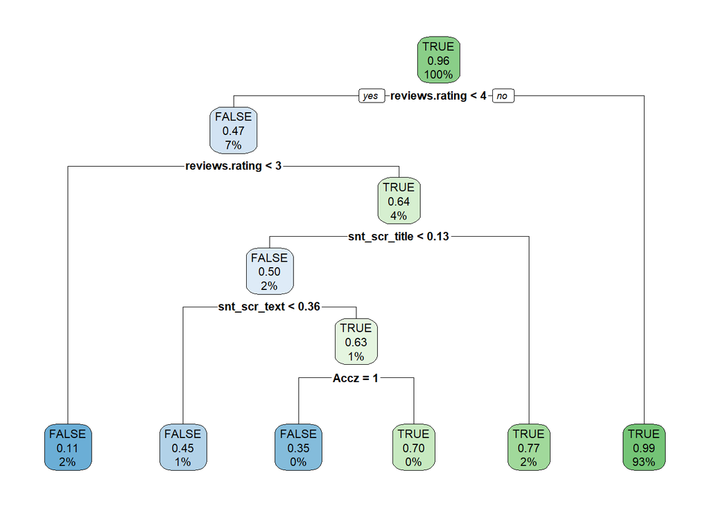

```r
set.seed(123)

final_decision_tree_model <- rpart(reviews.doRecommend ~ .,
                                   data = train_df3_b1,
                                   control = rpart.control(cp = best_cp))

rpart.plot(final_decision_tree_model, extra = 106)
```

```r
val_predictions <- predict(final_decision_tree_model, newdata = validation_df3_b1, type = "class")
val_predictions <- factor(val_predictions, levels = levels(validation_df3_b1$reviews.doRecommend))
actual_values <- validation_df3_b1$reviews.doRecommend

conf_matrix_dt <- confusionMatrix(val_predictions, actual_values)
conf_matrix_dt
```

```
## Confusion Matrix and Statistics
##
##           Reference
## Prediction FALSE TRUE
##      FALSE   163   58
##      TRUE    102 6489
##
##                Accuracy : 0.9765
##                  95% CI : (0.9726, 0.98)
##     No Information Rate : 0.9611
##     P-Value [Acc > NIR] : 9.666e-13
##
##                   Kappa : 0.6587
##
##  Mcnemar's Test P-Value : 0.0006752
##
##             Sensitivity : 0.61509
##             Specificity : 0.99114
##          Pos Pred Value : 0.73756
##          Neg Pred Value : 0.98452
##              Prevalence : 0.03890
##          Detection Rate : 0.02393
##    Detection Prevalence : 0.03244
##       Balanced Accuracy : 0.80312
##
##        'Positive' Class : FALSE
##
```

```r
suppressMessages(library(class))
```

### Running Random-Forest on business question 1 ‘train_df3_b1’.

```r
# Load the necessary library
suppressMessages(library(randomForest))

# Train the Random Forest model
rf_model_b1 <- randomForest(reviews.doRecommend ~ ., data = train_df3_b1)

# Print the model summary
print(rf_model_b1)
```

```
##
## Call:
##  randomForest(formula = reviews.doRecommend ~ ., data = train_df3_b1)
##                Type of random forest: classification
##                      Number of trees: 500
## No. of variables tried at each split: 3
##
##         OOB estimate of  error rate: 2.34%
## Confusion matrix:
##       FALSE  TRUE class.error
## FALSE   593   378 0.389289392
## TRUE    180 22693 0.007869541
```

```r
# Predict the probabilities
val_prob_b1_rf <- predict(rf_model_b1, newdata = validation_df3_b1, type = "prob")

# Convert probabilities to binary predictions (TRUE or FALSE) using a threshold of 0.5
val_predictions_b1_rf <- ifelse(val_prob_b1_rf[, "TRUE"] > 0.5, "TRUE", "FALSE")
val_predictions_b1_rf <- factor(val_predictions_b1_rf, levels = levels(validation_df3_b1$reviews.doRecommend))

# Create a confusion matrix
library(caret)
actual_values_b1 <- validation_df3_b1$reviews.doRecommend
conf_matrix_b1_rf <- confusionMatrix(val_predictions_b1_rf, actual_values_b1)
conf_matrix_b1_rf
```

```
## Confusion Matrix and Statistics
##
##           Reference
## Prediction FALSE TRUE
##      FALSE   148   45
##      TRUE    117 6502
##
##                Accuracy : 0.9762
##                  95% CI : (0.9723, 0.9797)
##     No Information Rate : 0.9611
##     P-Value [Acc > NIR] : 2.736e-12
##
##                   Kappa : 0.6343
##
##  Mcnemar's Test P-Value : 2.429e-08
##
##             Sensitivity : 0.55849
##             Specificity : 0.99313
##          Pos Pred Value : 0.76684
##          Neg Pred Value : 0.98232
##              Prevalence : 0.03890
##          Detection Rate : 0.02173
##    Detection Prevalence : 0.02833
##       Balanced Accuracy : 0.77581
##
##        'Positive' Class : FALSE
##
```

#### Building ROC curve to evaluate models built for business uestion 1.

```r
# Recreate the true_labels object
true_labels <- as.factor(validation_df3_b1$reviews.doRecommend)

# Run the previous code again
library(pROC)
# Logistic Regression
logit_probs <- predict(logit_model_unbalanced, validation_df3_b1, type = "response")
logit_roc <- roc(true_labels, logit_probs)
logit_df <- data.frame(Sensitivity = logit_roc$sensitivities,
                       Specificity = logit_roc$specificities,
                       Model = rep("Logistic Regression", length(logit_roc$sensitivities)))
print(dim(logit_df))
```

```
## [1] 6311    3
```

```r
# Decision Tree
dtree_probs <- predict(final_decision_tree_model, validation_df3_b1, type = "prob")[, "TRUE"]
dtree_roc <- roc(true_labels, dtree_probs)
dtree_df <- data.frame(Sensitivity = dtree_roc$sensitivities,
                       Specificity = dtree_roc$specificities,
                       Model = rep("Decision Tree", length(dtree_roc$sensitivities)))
print(dim(dtree_df))
```

```
## [1] 7 3
```

```r
# Random Forest
rforest_probs <- predict(rf_model_b1, validation_df3_b1, type = "prob")[, "TRUE"]
rforest_roc <- roc(true_labels, rforest_probs)
rforest_df <- data.frame(Sensitivity = rforest_roc$sensitivities,
                         Specificity = rforest_roc$specificities,
                         Model = rep("Random Forest", length(rforest_roc$sensitivities)))
print(dim(rforest_df))
```

```
## [1] 265   3
```

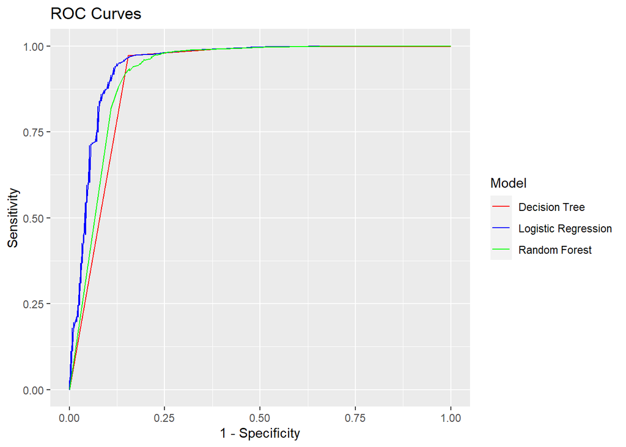

```r
roc_df <- rbind(logit_df, dtree_df, rforest_df)

ggplot(roc_df, aes(x = 1 - Specificity, y = Sensitivity, color = Model)) +
  geom_line() +
  labs(title = "ROC Curves",
       x = "1 - Specificity",
       y = "Sensitivity") +
  scale_color_manual(values = c("Logistic Regression" = "blue",
                                "Decision Tree" = "red",
                                "Random Forest" = "green"))
```

#### Caluclating AUROC (Area under Reciever operating curve)

```r
# Calculate AUROC for each model
logit_auc <- auc(logit_roc)
dtree_auc <- auc(dtree_roc)
rforest_auc <- auc(rforest_roc)

# Print AUROC values
cat("Logistic Regression AUROC:", logit_auc, "\n")
```

```
## Logistic Regression AUROC: 0.94566
```

```r
cat("Decision Tree AUROC:", dtree_auc, "\n")
```

```
## Decision Tree AUROC: 0.9148756
```

```r
cat("Random Forest AUROC:", rforest_auc, "\n")
```

```
## Random Forest AUROC: 0.9231522
```

## Business question 2:

### Predict whether customer is gonna give rating of 5 or not?

### Creating new dataset df3_b2 for this variable incorporting new binary variable ‘rating_is_5’ (True/False)

```r
# Create a new dataset 'df3_b2' from 'df3'
df3_b2 <- df3

# Create a binary variable for whether the rating is 5
df3_b2$rating_is_5 <- as.factor(df3_b2$reviews.rating == 5)

# Create a copy of the original dataset
df3_b2_original <- df3_b2
```

#### Creating a new dataset df3_b2 with new var ‘rating_is_5’ (True/False) and removing the var ‘reviews.rating’

```r
# Create a new dataset 'df3_b2' without the 'reviews.rating' variable
df3_b2 <- df3_b2 %>% select(-reviews.rating)

# Display the first few rows of the new dataset
head(df3_b2)
```

```
##   reviews.doRecommend Tblts AmzDvcs Accz Elec OffnBuss snt_scr_text
## 1                TRUE     1       0    0    0        0    0.3744226
## 2                TRUE     1       0    0    0        0    0.9827076
## 3                TRUE     1       0    0    0        0    0.8221922
## 4                TRUE     1       0    0    0        0    1.3969270
## 5                TRUE     1       0    0    0        0    0.8682080
## 6                TRUE     1       0    0    0        0    0.2867697
##   snt_scr_title snt_text_positive snt_title_positive rating_is_5
## 1     0.0000000              TRUE              FALSE        TRUE
## 2     1.0000000              TRUE               TRUE        TRUE
## 3     0.0000000              TRUE              FALSE        TRUE
## 4     0.7500000              TRUE               TRUE       FALSE
## 5     0.4330127              TRUE               TRUE        TRUE
## 6     0.2828427              TRUE               TRUE        TRUE
```

```r
names(df3_b2)
```

```
##  [1] "reviews.doRecommend" "Tblts"               "AmzDvcs"
##  [4] "Accz"                "Elec"                "OffnBuss"
##  [7] "snt_scr_text"        "snt_scr_title"       "snt_text_positive"
## [10] "snt_title_positive"  "rating_is_5"
```

```r
str(df3_b2)
```

```
## 'data.frame':    34064 obs. of  11 variables:
##  $ reviews.doRecommend: logi  TRUE TRUE TRUE TRUE TRUE TRUE ...
##  $ Tblts              : num  1 1 1 1 1 1 1 1 1 1 ...
##  $ AmzDvcs            : num  0 0 0 0 0 0 0 0 0 0 ...
##  $ Accz               : num  0 0 0 0 0 0 0 0 0 0 ...
##  $ Elec               : num  0 0 0 0 0 0 0 0 0 0 ...
##  $ OffnBuss           : num  0 0 0 0 0 0 0 0 0 0 ...
##  $ snt_scr_text       : num  0.374 0.983 0.822 1.397 0.868 ...
##  $ snt_scr_title      : num  0 1 0 0.75 0.433 ...
##  $ snt_text_positive  : logi  TRUE TRUE TRUE TRUE TRUE TRUE ...
##  $ snt_title_positive : logi  FALSE TRUE FALSE TRUE TRUE TRUE ...
##  $ rating_is_5        : Factor w/ 2 levels "FALSE","TRUE": 2 2 2 1 2 2 1 2 2 2 ...
```

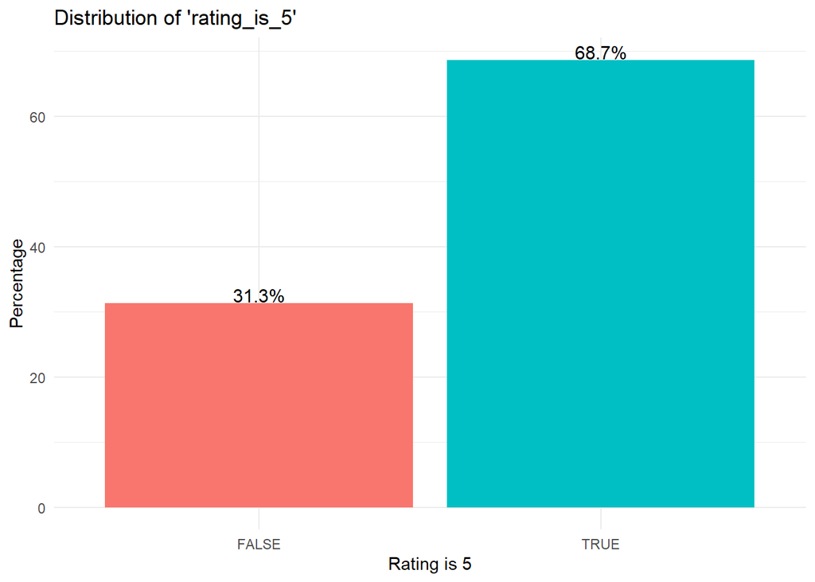

```r
# Compute the percentage for each level of rating_is_5
rating_is_5_counts <- table(df3_b2$rating_is_5)
rating_is_5_percentages <- rating_is_5_counts / sum(rating_is_5_counts) * 100

# Create a data frame with the percentage values
rating_is_5_data <- data.frame(
  rating_is_5 = names(rating_is_5_percentages),
  percentage = as.numeric(rating_is_5_percentages)
)

# Create the bar plot with percentage labels
ggplot(rating_is_5_data, aes(x = rating_is_5, y = percentage, fill = rating_is_5)) +
  geom_bar(stat = "identity") +
  geom_text(aes(label = paste0(round(percentage, 1), "%")), vjust = -0.08, size = 4) +
  theme_minimal() +
  labs(x = "Rating is 5", y = "Percentage", title = "Distribution of 'rating_is_5'") +
  theme(legend.position = "none")
```

### I think here distribution is not as imbalanced and maybe we should train the model over the imbalanced training data..however we will test the both models accuracy/precision of original training data and of balanced training data.